# QAOA vs Solver Classici per Minimum Vertex Cover

**Domanda di ricerca**

> A parità di dimensione del problema, QAOA con profondità crescente $p$ riesce a competere con i migliori ottimizzatori classici in termini di *approximation ratio*? Come cambia questo risultato in presenza di rumore simulato e su hardware IBM reale?

**Struttura del notebook**

> Il lavoro è organizzato in 5 sezioni:
> 1. La Sezione 1 definisce il problema e la formulazione matematica.
> 2. La Sezione 2 implementa e testa i solver classici.
> 3. La Sezione 3 implementa QAOA e lo testa in tre regimi di rumore crescente.
> 4. La Sezione 4 esegue QAOA su hardware IBM reale.
> 5. La Sezione 5 confronta tutto in modo equo usando il *miglior p* per istanza.

## 1. Inizializzazione

### Parametri dell'esperimento

La scelta del numero massimo di vertici nei grafi $N \leq 10$ e del numero di istanze $N_{INST} \leq 20$ è dovuta alla complessità spaziale e temporale intrinseca alla simulazione classica dei sistemi quantistici.

1. **Vincolo 1 — Memoria State Vector $\mathcal{O}(2^N)$ (Simulazione Ideale)** Lo *state vector* richiede il mantenimento in memoria di $2^N$ ampiezze complesse [1]. Sebbene per $N \leq 20$ la memoria richiesta sia nell'ordine dei megabyte e gestibile localmente, limitare l'esperimento a $N \leq 10$ assicura risultati comparabili per confronti futuri.
2. **Vincolo 2 — Memoria Density Matrix $\mathcal{O}(4^N)$ (Simulazione con Rumore)** L'introduzione di modelli di rumore reali vede l'abbandono dello state vector in favore della *density matrix*, la cui richiesta spaziale aumenta a $2^N \times 2^N = \mathcal{O}(4^N)$ [1, 4]. A $N=16$, una density matrix richiede già $\sim 64$ GB di RAM. È stato dimostrato che i moderni supercomputer exascale non riescono a simulare matrici densità oltre $N=25$ [5, 6]. Di conseguenza, simulare il QAOA con depolarizing noise su una macchina consumer impone un hard-limit stringente attorno a $N=10$.

> **Riferimenti Bibliografici:** [1] Nielsen, M. A., & Chuang, I. L. (2010). *Quantum Computation and Quantum Information*. [2] Jamadagni et al., "A Herculean task: Classical simulation of quantum computers", *Science Bulletin* (2025). [3] Liu et al., "Quantum-centric Supercomputing for Materials Science", arXiv:2312.09733 (2023). [4] Broughton et al., "TensorFlow Quantum: A Software Framework for QML", arXiv:2003.02989 (2020). [5] Patel et al., "Accelerating Simulation of Quantum Circuits under Noise...", *ISCA* (2025). [6] Tang et al., "Noisy Quantum Simulation Using Tracking, Uncomputation...", arXiv:2508.04880 (2025).

La scelta di probabilità di connessione variabili nell'algoritmo di Erdős–Rényi permette di testare l'algoritmo su grafi sparsi, mediamente densi e molto densi.

L'impostazione di un seed per-istanza garantisce grafi riproducibili; il seed globale rende deterministica l'inizializzazione dei parametri e del noise model.

Esplorare la profondità del circuito da 1 a 5 layer serve a testare il compromesso tra la teoria e la pratica. Teoricamente, all'aumentare di $p$ il QAOA approssima sempre meglio la soluzione ottima. Tuttavia, simulare fino a profondità $p=5$ genera un circuito che, su macchine hardware reali o simulatori con rumore, accumulerà un tasso di errore elevato.

Un N_SHOTS pari a 1024 è usato al fine di avere statistiche affidabili.

La granularità adottata nei livelli di rumore, dal caso ideale fino al 15%, è pensata per tracciare la curva di degrado delle prestazioni. Il rumore appiattisce la funzione di costo (noise-induced barren plateaus).

```python
import os
from dotenv import load_dotenv
load_dotenv()
IBM_API_KEY = os.getenv("IBM_API_KEY")

# ── Dimensioni e istanze ──────────────────────────────────────────────────
SIZES        = [6, 8, 10]               # dimensioni algoritmi classici
N_INST       = 20                       # istanze per dimensione
EDGE_P       = [0.25, 0.5, 0.75]        # probabilità arco Erdős–Rényi
GLOBAL_SEED  = 42                       # seed globale per riproducibilità

# ── Parametri QAOA ───────────────────────────────────────────────────────
P_LIST       = [1, 2, 3,  4, 5]         # profondità del circuito
MAX_ITER     = 200                      # iterazioni massime COBYLA
N_SHOTS      = 1024                     # campioni per valutazione
NOISE_LEVELS = [0.0, 0.005, 0.01, 0.02, 0.05, 0.08, 0.10, 0.15]

# ── Checkpoint ───────────────────────────────────────────────────────────
import os
os.makedirs("cache", exist_ok=True)
CACHE_CLASSICAL = "cache/classical.pkl"
CACHE_QAOA      = "cache/qaoa.pkl"
CACHE_AER       = "cache/aer.pkl"
CACHE_IBM       = "cache/ibm.pkl"

print("Parametri configurati ✓")
```

```
Parametri configurati ✓
```

### Panoramica del Modulo `utils/`

Per mantenere il notebook pulito e focalizzato sulla logica degli algoritmi, tutta la gestione dei dati, le conversioni matematiche e i codici di plotting sono stati astratti e modulati all'interno della cartella `utils/`.

Di seguito le funzioni importate:

**1. Formulazione Matematica (`utils/qubo.py`)**

- `build_qubo()`: Costruisce la matrice QUBO associata al Minimum Vertex Cover a partire da un grafo *NetworkX*.
- `qubo_to_ising()`: Effettua la conversione di variabili spin-bit mappando la matrice QUBO in coefficienti del modello di Ising (matrice interazioni $J$ e campo magnetico locale $h$).

**2. Generazione e Gestione Grafi (`utils/graph.py`)**

- `make_all()`: Motore di generazione dati. Inizializza l'intero dataset di grafi casuali Erdős–Rényi iterando su dimensioni, istanze e probabilità di connessione.
- `valid()`: Verifica booleana che assicura che il set di vertici restituito da un algoritmo sia una copertura valida per il grafo.
- `repair()`: Euristica golosa (Greedy) utilizzata dal Simulated Annealing e dal QAOA per forzare la validità di una cover: se restano archi scoperti, aggiunge nodi in modo sub-ottimale ma sicuro.
- `agg()`: Funzione di aggregazione statistica che raggruppa liste di risultati calcolandone medie e deviazioni standard.

**3. Strutture Dati e Utility**

- `R`: Classe (DataClass) che standardizza un "Risultato" di un esperimento, memorizzando per ogni run: nome del solver, dimensione $N$, ID istanza, size della cover, tempo di calcolo e Approximation Ratio.
- `STYLE`, `COLORS_P`: Dizionari contenenti la palette di colori e stili di linea, garantendo uniformità cromatica tra tutti i grafici del paper.

**4. Visualizzazione e Reportistica (`utils/display.py`)**

- `plot_*`: Un gruppo di funzioni che nascondono il codice ripetitivo per la formattazione dei grafici.
- `print_*_table`: Metodi per la tabulazione riassuntiva dei dati aggregati.

```python
import warnings; warnings.filterwarnings("ignore")
import sys, time, math, random, shutil, subprocess, pickle
sys.path.insert(0, os.getcwd())
#sys.path.insert(0, os.path.dirname(os.path.abspath("__file__")))

import numpy as np
import networkx as nx
import matplotlib.pyplot as plt
import pennylane as qml
from scipy.optimize import minimize
#from tqdm.notebook import tqdm
from tqdm import tqdm

# ── Plumbing statico (utils/) ─────────────────────────────────────────────
from utils import (
    R, make_all, valid, repair, agg,
    build_qubo, qubo_to_ising,
    STYLE, COLORS_P, console,
    print_summary_table, print_aer_comparison_table, print_ibm_comparison_table,
    plot_mvc_examples, plot_qubo_matrix, plot_ratio_vs_n, plot_time_vs_n,
    plot_noise_sweep, plot_heatmap, plot_cobyla_convergence,
    plot_bitstring_distribution, plot_ibm_comparison, plot_aer_vs_pl_bars,
    plot_ratio_vs_edge_p, plot_qaoa_vs_p, plot_qaoa_depth_vs_density,
    print_p_opt_summary, load_cache, save_cache, calc_probs
)

ALL = make_all(sizes=SIZES, n_inst=N_INST, edge_p=EDGE_P)
print(f"Librerie caricate |  {sum(len(v) for v in ALL.values())} grafi generati")

# ── Solver aggregato: "miglior p per istanza" per confronto ────────
import utils.display as _disp
_disp.STYLE["qaoa_best"]   = {"c": "#d62728", "ls": "-", "m": "v", "lbl": "QAOA (best p)"}
_disp.PARADIGM["qaoa_best"] = "Quantistico"
STYLE["qaoa_best"] = _disp.STYLE["qaoa_best"]   # sync locale
```

```
Librerie caricate |  180 grafi generati
```

### Definizione del Problema: Minimum Vertex Cover

Dato $G=(V,E)$, trovare $S^* \subseteq V$ di cardinalità minima tale che $\forall (u,v)\in E:~u\in S \lor v\in S$.

- **NP-Hard** (NP-Completo nella versione decisionale)
- Equivalente a **Maximum Independent Set** per complemento
- Migliore approssimazione polinomiale garantita: $2\text{-OPT}$

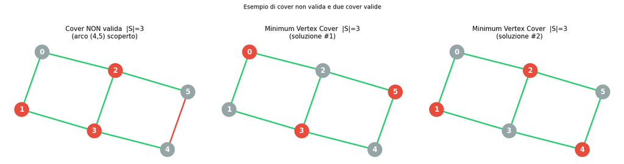

```python
plot_mvc_examples()
```

### Formulazione QUBO

Consideriamo una variabile binaria $x_v \in \{0,1\}$ per ogni vertice del grafo, dove $x_v = 1$ indica che il vertice $v$ è incluso nella cover.

Il problema viene descritto dalla funzione di costo:

$$H(\mathbf{x}) = A \sum_{(u,v) \in E}(1-x_u)(1-x_v) + B \sum_v x_v, \quad A \gg B $$

Il primo termine fornisce una penalità ogni volta che un arco $(u,v)$ non è coperto, cioè quando entrambi i vertici $u$ e $v$ non appartengono alla cover. Il secondo termine penalizza invece, la dimensione della cover.

La scelta $A \gg B$ impone che la priorità del modello sia evitare archi scoperti, anche a costo di includere più vertici nella soluzione.

La funzione $H(\mathbf{x})$ può essere scritta in forma quadratica introducendo la matrice $Q$:

- i termini diagonali $Q_{vv} = B - A \cdot \text{deg}(v)$ derivano dalla combinazione tra costo del vertice e contributo degli archi incidenti
- i termini fuori diagonale $Q_{uv} = A/2$ derivano dai prodotti $x_u x_v$ presenti nella espansione del primo termine

In questo modo, l’intera funzione $H(\mathbf{x})$ è completamente rappresentata dalla matrice $Q$: i termini diagonali favoriscono i vertici ad alto grado, mentre i termini fuori diagonale penalizzano configurazioni in cui entrambi gli estremi di un arco vengono esclusi.

Per passare alla formulazione di Ising si introduce la trasformazione: $$x_v = \frac{1 - z_v}{2}$$ che mappa la variabile binaria $x_v$ in una variabile di spin $z_v \in \{-1, +1\}$, con:

- $z_v = +1$ → vertice escluso dalla cover
- $z_v = -1$ → vertice incluso nella cover

Sostituendo questa relazione nella funzione di costo si ottiene l’Hamiltoniano di Ising: $$H_C = \sum_{i<j} J_{ij} Z_i Z_j + \sum_i h_i Z_i + \text{offset}$$ dove:

- $Z_i \in \{-1, +1\}$ rappresenta la variabile di spin associata al vertice $i$
- $J_{ij}$ contiene i coefficienti derivati dalla matrice $Q$ relativi alle interazioni tra vertici
- $h_i$ contiene i coefficienti lineari associati ai singoli vertici
- l’offset è una costante indipendente dallo stato e non influisce sull’ottimizzazione

Il significato della funzione di costo è il seguente: ogni arco non coperto contribuisce $+A$, ogni vertice incluso nella cover contribuisce $+B$. Poiché $A > B$, minimizzare $H(\mathbf{x})$ equivale a evitare archi scoperti nel modo più efficiente possibile, riducendo al minimo il numero di vertici selezionati. Pertanto, il minimo globale di $H(\mathbf{x})$ corrisponde a una soluzione ottima per Minimum Vertex Cover.

Di seguito, viene mostrata una HeatMap della matrice QUBO per un grafo composto da 4 nodi.

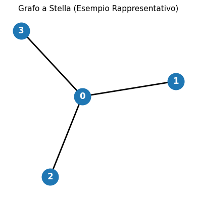

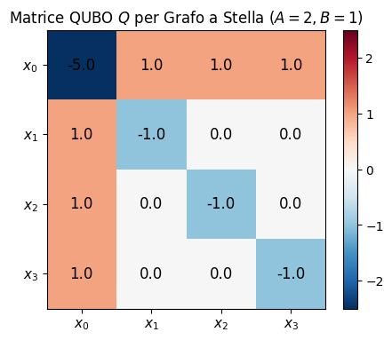

```python
# Grafo a stella: il nodo 0 è al centro, connesso a 1, 2 e 3
G4 = nx.star_graph(3)
G4.graph["instance_id"] = 0

fig, ax = plt.subplots(figsize=(4, 4))
pos = nx.spring_layout(G4, seed=42)

nx.draw_networkx(G4, pos=pos,
                 ax=ax, node_color="#1f77b4", node_size=550,
                 font_color="white", font_weight="bold", width=2)
ax.set_title("Grafo a Stella (Esempio Rappresentativo)", fontsize=11)
ax.axis("off")
plt.tight_layout()
plt.show()

# Matrice QUBO
G4.graph["instance_id"] = 0
plot_qubo_matrix(build_qubo(G4), title="Matrice QUBO $Q$ per Grafo a Stella $(A=2, B=1)$")
```

I valori negativi sulla diagonale (blu) indicano che il minimizzatore è "incentivato" a includere quel vertice nella cover — più è negativo, più il vertice è utile. I valori positivi off-diagonali (rosso) penalizzano le coppie di vertici adiacenti entrambi esclusi.

Si vede infatti, che la soluzione migliore è data dalla selezione di $x_0$, mentre le soluzioni non ottimali includono la selezione degli altri tre nodi.

## 2. Applicazione Algoritmi Classici

In questa sezione vengono testati tre solver classici, facendoli girare sulle stesse istanze e valutandoli con la stessa metrica, così da avere un benchmark pulito e diretto.

| Solver | Complessità | Garanzia |
| --- | --- | --- |
| Branch & Bound | Esponenziale | Esatto — ground truth |
| Greedy | $O(n^2)$ | $\le \log \Delta$-approssimazione |
| Simulated Annealing | $O(n \cdot \text{iter})$ | Euristica stocastica |

La metrica che usiamo per tutti è l'**approximation ratio** ($\text{ratio} = \frac{|S|}{|S^*|}$), dove $|S^*|$ è l'ottimo esatto tirato fuori dal Branch & Bound. In sintesi: un ratio pari a 1 significa che abbiamo beccato la soluzione ottima; più ci allontaniamo da 1, peggiore sarà l'approssimazione ottenuta.

### 2.1 Branch & Bound

Il Branch & Bound è l'unico solver che garantisce la soluzione esatta. Il problema è che esplora un albero di ricerca che nel caso peggiore ha $2^N$ nodi. Tuttavia, questo viene mitigato da una strategia di pruning: si potano i rami inutili appena ci si accorge che non possono portare a niente di buono. I due meccanismi di potatura sono:

- Upper bound: se la cover che sto costruendo è già grande quanto la migliore trovata finora, qualunque cosa aggiunga non migliorerà — taglio il ramo.
- Lower bound con matching massimale: tra gli archi ancora scoperti, trovo un matching massimale (archi che non si toccano). Ognuno di questi archi richiede almeno un vertice in più nella cover. Se $|\text{cover}| + |\text{matching}| \geq \text{best}$, anche nel migliore dei casi non riesco a fare meglio — taglio il ramo.

La cosa interessante del secondo punto è che non aspetto di finire la cover per capire se è buona: il minimo numero di vertici che serviranno alla realizzazione della cover viene stimato in anticipo e, se la stima è già troppo alta, l'algoritmo termina prima. Come upper bound iniziale viene usata una cover realizzata prendendo iterativamente il nodo con max degree: in questo modo è immediatamente disponibile un upper bound da cui partire, e il pruning è già efficace dalla prima iterazione.

```python
def _lb(unc):
    matched, k = set(), 0
    for u, v in unc:
        if u not in matched and v not in matched:
            matched |= {u, v}; k += 1
    return k

def _bb(edges, cover, best):
    unc = [(u, v) for u, v in edges if u not in cover and v not in cover]
    if not unc:
        if len(cover) < len(best[0]): best[0] = cover
        return
    if len(cover) >= len(best[0]) or len(cover) + _lb(unc) >= len(best[0]): return
    u, v = unc[0]
    _bb(edges, cover | {u}, best)
    _bb(edges, cover | {v}, best)

def bb(G):
    H = G.copy(); ub = set()
    while H.number_of_edges():
        nd = max(H.nodes(), key=H.degree); ub.add(nd); H.remove_node(nd)
    best = [frozenset(ub)]; t0 = time.perf_counter()
    _bb(list(G.edges()), frozenset(), best)
    cov = set(best[0])
    return R("branch_and_bound", G.number_of_nodes(), G.graph["instance_id"],
             len(cov), len(cov), 1.0, time.perf_counter() - t0, True)
```

Il ratio $= 1.0$ nel risultato è fisso per definizione: questo solver è il ground truth su cui tutti gli altri vengono misurati.

### 2.2 Greedy

Il Greedy fa una cosa sola, in loop: prende il vertice con il grado più alto nel grafo residuo, lo aggiunge alla cover, lo elimina dal grafo insieme a tutti i suoi archi, e ripete, terminando quando non ci sono più archi.

L'intuizione è semplice: un nodo con grado alto copre tanti archi in un colpo solo, quindi conviene prenderlo subito. È una strategia puramente locale, poichè non si guarda mai "più in là" di un passo, e questo significa che non c'è nessuna garanzia di ottimalità.

```python
def greedy(G, opt=-1):
    t0 = time.perf_counter(); H = G.copy(); cov = set()
    while H.number_of_edges():
        nd = max(H.nodes(), key=lambda v: (H.degree(v), -v))
        cov.add(nd); H.remove_node(nd)
    sz = len(cov)
    return R("greedy", G.number_of_nodes(), G.graph["instance_id"],
             sz, opt, sz / opt if opt > 0 else -1, time.perf_counter() - t0, True)
```

Il criterio `(H.degree(v), -v)` serve solo a rompere i pareggi in modo deterministico: a parità di grado, vince il nodo con indice più basso. Così i risultati sono riproducibili indipendentemente dall'ordine interno della struttura dati.

### 2.3 Simulated Annealing

Il Simulated Annealing si ispira alla ricottura dei metalli: quando un metallo viene raffreddato lentamente, gli atomi trovano il tempo di sistemarsi nelle configurazioni a energia minima. Se lo si raffredda troppo in fretta, gli atomi restano bloccati in stati sub-ottimali. L'idea è usare la stessa logica per l'ottimizzazione: permettersi di fare mosse "sbagliate" all'inizio, per evitare di restare intrappolati in minimi locali. La funzione di energia è esattamente la funzione QUBO che abbiamo già visto: $$E(\mathbf{x}) = A\sum_{(u,v)}(1-x_u)(1-x_v) + B\sum_v x_v$$ Si parte da una cover completa ($x=1$, tutti i vertici dentro) e ad ogni iterazione si prova a flippare un singolo bit. Le regole sono:

- Se la mossa migliora l'energia allora si accetta sempre.
- Se la mossa peggiora l'energia di $\Delta E$, allora si accetta la mossa con probabilità $e^{-\Delta E / T}$.

La temperatura $T$ scende secondo lo schedule $T_k = T_0 \cdot \alpha^k$: all'inizio è alta e il sistema accetta spesso anche mosse peggiorative (esplora), poi man mano che $T \to 0$, l'algoritmo diventa selettivo e converge. Se alla fine rimangono archi scoperti, a causa del flip finale, `repair()` aggiusta la cover in modo greedy per garantire che sia valida.

```python
def sa(G, opt=-1, T0=2.0, alpha=0.995, iters=50_000, A=10.0, B=1.0, seed=GLOBAL_SEED):
    rng = random.Random(seed)
    nodes = list(G.nodes()); n = len(nodes)
    adj   = {v: [] for v in nodes}
    for u, v in G.edges(): adj[u].append(v); adj[v].append(u)
    nbr_idx = {i: [nodes.index(u) for u in adj[nodes[i]]] for i in range(n)}

    x = [1] * n; T = T0
    def dE(vi):
        xv_new = 1 - x[vi]
        return (B * (xv_new - x[vi]) +
                A * sum((1-x[j])*(1-xv_new) - (1-x[j])*(1-x[vi]) for j in nbr_idx[vi]))

    best_x = x[:]; best_E = float(B * n); t0 = time.perf_counter()
    for _ in range(iters):
        vi = rng.randint(0, n - 1); de = dE(vi)
        if de < 0 or rng.random() < math.exp(-de / max(T, 1e-10)):
            x[vi] = 1 - x[vi]
            E = sum(x) * B
            if E < best_E: best_E = E; best_x = x[:]
        T *= alpha

    cov = repair(G, {nodes[i] for i, b in enumerate(best_x) if b}); sz = len(cov)
    return R("simulated_annealing", G.number_of_nodes(), G.graph["instance_id"],
             sz, opt, sz / opt if opt > 0 else -1, time.perf_counter() - t0, valid(G, cov))
```

### 2.4 Benchmark

I tre solver vengono eseguiti sulle stesse 180 istanze generate nella Sezione 1 (tre dimensioni $N \in \{6, 8, 10\}$, venti grafi per ciascuna delle tre densità). Per ogni grafo, Branch & Bound gira per primo e fornisce $|S^*|$, poi Greedy e SA vengono valutati rispetto a quel valore.

I risultati sono salvati in `cache/classical.pkl` per evitare riesecuzioni, nel caso di parametri uguali.

```python
CONFIG_CLASSICAL = {
    "sizes":      SIZES,
    "n_inst":     N_INST,
    "edge_p":     EDGE_P,
    "sa_T0":      2.0,
    "sa_alpha":   0.995,
    "sa_iters":   50_000,
}

if os.path.exists(CACHE_CLASSICAL):
    cached = pickle.load(open(CACHE_CLASSICAL, "rb"))
    if isinstance(cached, dict) and cached.get("config") == CONFIG_CLASSICAL:
        CLASSICAL = cached["results"]
        print(f"Checkpoint caricato: {len(CLASSICAL)} risultati")
    else:
        print("⚠️  Cache nel vecchio formato o parametri cambiati. Ricalcolo in corso...")
        CLASSICAL = None
else:
    CLASSICAL = None

if CLASSICAL is None:
    SOLVERS_CL = [
        ("branch_and_bound",    lambda G, opt: bb(G)),
        ("greedy",              lambda G, opt: greedy(G, opt)),
        ("simulated_annealing", lambda G, opt: sa(G, opt)),
    ]
    CLASSICAL = []
    for n in tqdm(SIZES, desc="Dimensioni"):
        for G in tqdm(ALL[n], desc=f"  N={n}", leave=False):
            opt_r = bb(G); opt = opt_r.sz
            CLASSICAL.append(opt_r)
            for _, fn in SOLVERS_CL[1:]:
                CLASSICAL.append(fn(G, opt))

    pickle.dump({"config": CONFIG_CLASSICAL, "results": CLASSICAL},
                open(CACHE_CLASSICAL, "wb"))
    print(f"Benchmark completato: {len(CLASSICAL)} risultati — checkpoint salvato")
```

```
Checkpoint caricato: 540 risultati
```

La seguente tabella confronta la qualità delle soluzioni trovate dai vari algoritmi al crescere della dimensione del problema ($N$).

```python
print_summary_table(CLASSICAL)
```

```
                       Confronto parziale dei Solver Classici
╔══════════════════════╤════════════╤════════════╤════════════╤════════════╤════════╗
║ Solver               │  Avg Ratio │  Std Ratio │  Max Ratio │  Avg t (s) │      n ║
╟──────────────────────┼────────────┼────────────┼────────────┼────────────┼────────╢
║ Branch & Bound       │     1.0000 │     0.0000 │     1.0000 │     0.0001 │    180 ║
║ Greedy               │     1.0194 │     0.0674 │     1.5000 │     0.0001 │    179 ║
║ Sim. Annealing       │     1.0138 │     0.0533 │     1.3333 │     0.0625 │    179 ║
╚══════════════════════╧════════════╧════════════╧════════════╧════════════╧════════╝
```

Il valore $1.0$ rappresenta la soluzione migliore possibile, individuata da Branch & Bound. Greedy e Simulated Annealing, invece, trovano soluzioni leggermente peggiori. Infatti, il loro valore si discosta da $1.0$.

Possiamo osservare il confronto graficamente, nell'immagine riportata di seguito.

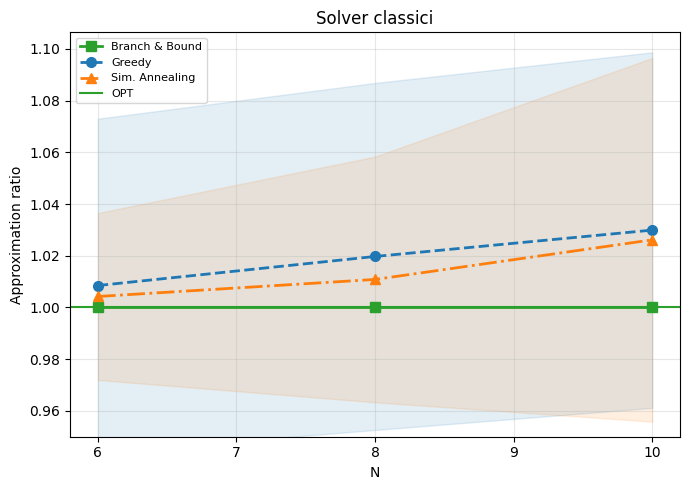

```python
plot_ratio_vs_n(CLASSICAL)
```

In questo grafico, la fascia attorno alle curve rappresenta la variabilità dei risultati (deviazione standard): una fascia più ampia indica che le prestazioni dell'algoritmo sono meno stabili, mentre una fascia più stretta indica risultati più consistenti.

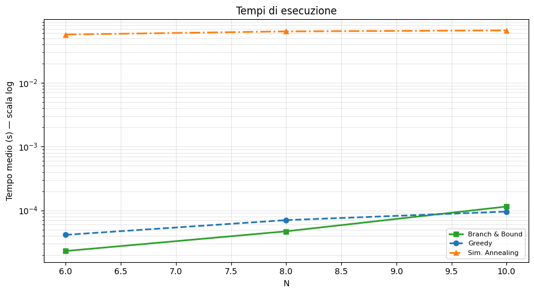

```python
plot_time_vs_n(CLASSICAL)
```

## 3. Applicazione di QAOA su HW Quantistico Simulato

### Definizione

QAOA è un algoritmo quantistico che cerca gradualmente di concentrarsi sulle soluzioni migliori del problema.

Per farlo alterna due operazioni, ripetute per un certo numero di strati.

1. La prima operazione (**Phase Separator**) valuta la qualità delle soluzioni: le soluzioni migliori vengono modificate poco, mentre quelle peggiori vengono modificate di più.
2. La seconda operazione (**Mixer**) rimescola le possibili soluzioni, permettendo all'algoritmo di esplorare nuove alternative invece di rimanere bloccato su quelle già trovate.

Ripetendo queste due fasi, le soluzioni migliori tendono a rafforzarsi tra loro, mentre quelle peggiori tendono a indebolirsi. In questo modo aumenta progressivamente la probabilità di ottenere una soluzione di buona qualità quando si effettua la misura finale.

I parametri $\gamma$ e $\beta$ regolano rispettivamente quanto peso viene dato alla qualità delle soluzioni e quanto intensamente queste vengono rimescolate.

Per valutare le prestazioni dell'algoritmo, QAOA viene testato in due diversi ambienti simulati:

- **PennyLane**: un simulatore ideale a cui viene aggiunto un rumore controllato e uniforme.
- **Qiskit Aer**: un simulatore più realistico che riproduce gli errori tipici dell'hardware quantistico reale, come errori nei gate, decoerenza dei qubit ed errori di lettura delle misure.

Prima di costruire il circuito quantistico, vengono definite due funzioni di supporto per interpretare correttamente i risultati delle misurazioni.

1. La prima funzione, `_samples_to_counts`, prende l'output grezzo prodotto dal simulatore e lo trasforma in un formato più semplice da analizzare. Nello specifico, conta quante volte è comparsa ciascuna soluzione e restituisce una tabella del tipo "soluzione $\to$ numero di occorrenze".
2. La seconda funzione, `_best_cover`, è quella che seleziona la soluzione finale, che non è quella più frequente. Infatti, la funzione controlla tutte le soluzioni ottenute e cerca quella valida che utilizza il minor numero possibile di nodi. Se tra le soluzioni campionate non ce n'è nessuna valida, viene applicata una procedura di correzione (repair) che modifica una soluzione in modo greedy fino a renderla valida.

Si potrebbe anche usare un unico metodo per tutto il processo, ma in pratica conviene separare le due fasi. Questo perchè, durante l’ottimizzazione è più utile lavorare con un calcolo esatto, in quanto rende il processo più stabile e permette all’algoritmo di convergere meglio. Analogamente, il campionamento con shots, invece, viene lasciato alla fase finale perché serve solo a trasformare la soluzione teorica in risultati concreti (i bitstring).

```python
def _samples_to_counts(samples):
    counts = {}
    for row in samples:
        k = tuple(int(b) for b in row); counts[k] = counts.get(k, 0) + 1
    return counts

def _best_cover(G, counts):
    """Cover valida di dimensione minima tra i bitstring campionati."""
    nodes = list(G.nodes()); best_cov, best_sz = None, len(nodes) + 1
    fallback = None
    for bs in sorted(counts, key=lambda k: -counts[k]):
        cov = {nodes[i] for i, b in enumerate(bs) if b}
        if valid(G, cov):
            if len(cov) < best_sz: best_sz = len(cov); best_cov = cov
        elif fallback is None: fallback = cov
    return best_cov if best_cov is not None else repair(G, fallback or set())
```

### 3.1 Implementazione del Circuito (PennyLane)

L’implementazione del circuito è organizzata in tre funzioni separate, ognuna con un ruolo preciso nella pipeline QAOA.

1. La funzione `make_qaoa` costruisce il circuito e serve durante l’ottimizzazione. Riceve i parametri del modello e calcola direttamente il valore atteso dell’energia del sistema. Non esegue campionamenti: lavora in modo “esatto” usando lo statevector. È questa la funzione che l’ottimizzatore COBYLA usa a ogni iterazione per capire se i parametri stanno migliorando o peggiorando la soluzione.
2. La seconda funzione, `make_sampler`, usa lo stesso circuito ma con uno scopo diverso: invece di calcolare un valore “teorico” preciso, esegue il circuito molte volte e raccoglie i risultati come bitstring.
3. La terza funzione, `run_qaoa`, collega tutto in una pipeline completa:
   - Costruisce il problema in forma QUBO e lo trasforma in Ising;
   - Inizializza i parametri in modo casuale;
   - Ottimizza i parametri usando COBYLA sul circuito costruito dalla funzione `make_qaoa`;
   - Esegue il campionamento finale con `make_sampler` per estrarre valori concreti;
   - Seleziona la soluzione migliore e restituisce tutto in un oggetto finale.

Segue il circuito: $$|\psi_0\rangle = |+\rangle^{\otimes n} \xrightarrow{\displaystyle\prod_{l=1}^{p} U_C(\gamma_l)\, U_B(\beta_l)} |\psi_p(\boldsymbol{\gamma},\boldsymbol{\beta})\rangle$$

Ogni qubit $i$ rappresenta un vertice del grafo:

- Il valore $|1\rangle$ di un qubit significa che il vertice ad esso associato è incluso nella cover;
- Il valore $|0\rangle$ di un qubit significa che il vertice ad esso associato è escluso dalla cover.

Il circuito parte con il gate **Hadamard** su ogni qubit, che prepara lo stato iniziale $|+\rangle^{\otimes n}$: fa in modo che tutte le soluzioni abbiano la stessa probabilità, senza fare preferenze. I gate successivi sono la traduzione diretta dei termini dell'Hamiltoniano di Ising in operazioni quantistiche.

Il **phase separator** $U_C(\gamma) = e^{-i\gamma H_C}$ ruota la fase di ogni stato in proporzione al suo costo $H_C$ : gli stati che rappresentano cover buone ruotano poco, quelli che rappresentano cover peggiori ruotano tanto. $H_C$ usa l'operatore $Z_i$ (Pauli-Z), che come visto in Sezione 1 vale $+1$ se il vertice è escluso e $-1$ se è incluso. È implementato da due gate:

- **IsingZZ** — gestisce i termini $J_{ij}Z_iZ_j$: penalità per gli archi scoperti.
- **RZ** — gestisce i termini $h_iZ_i$: costo individuale di ogni vertice.

Il **mixer** $U_B(\beta)$ invece non penalizza nulla: applica un gate **RX** a ogni qubit, che mescola $|0\rangle$ e $|1\rangle$ permettendo all'algoritmo di spostarsi tra soluzioni diverse. Senza di lui il circuito non esplorerebbe nulla.

|  | Funzione |
| --- | --- |
| $\boxed{H}$ | **Hadamard** — superposizione uniforme: si parte senza preferenze. |
| $\boxed{ZZ}$ | **IsingZZ** — penalizza gli archi scoperti. |
| $\boxed{RZ}$ | **RZ** — penalizza le cover grandi. |
| $\boxed{RX}$ | **RX** — esplora nuove soluzioni. |

I parametri $(\boldsymbol{\gamma}, \boldsymbol{\beta})$ verranno ottimizzati con l'ottimizzatore **COBYLA**.

```python
def make_qaoa(n, p, J, h, dev):
    """QNode che restituisce ⟨ψ_p|H_C|ψ_p⟩ — usato da COBYLA per l'ottimizzazione."""
    @qml.qnode(dev, diff_method="parameter-shift")
    def circuit(params):
        gammas, betas = params[:p], params[p:]
        for i in range(n): qml.Hadamard(wires=i)
        for layer in range(p):
            g, b = gammas[layer], betas[layer]
            for i in range(n):
                for j in range(i+1, n):
                    if abs(J[i,j]) > 1e-10: qml.IsingZZ(2*g*J[i,j], wires=[i,j])
            for i in range(n):
                if abs(h[i]) > 1e-10: qml.RZ(2*g*h[i], wires=i)
            for i in range(n): qml.RX(2*b, wires=i)
        terms = ([J[i,j]*qml.PauliZ(i)@qml.PauliZ(j)
                  for i in range(n) for j in range(i+1,n) if abs(J[i,j])>1e-10] +
                 [h[i]*qml.PauliZ(i) for i in range(n) if abs(h[i])>1e-10])
        return (qml.expval(qml.Hamiltonian([1.0]*len(terms), terms))
                if terms else qml.expval(qml.Identity(0)))
    return circuit

def make_sampler(n, p, J, h, dev_s, noisy=False, noise_prob=0.0):
    """QNode con shots — campiona bitstring dal circuito QAOA."""
    def _dep(ws):
        if noisy:
            for w in ws: qml.DepolarizingChannel(noise_prob, wires=w)
    @qml.qnode(dev_s)
    def circuit(params):
        gammas, betas = params[:p], params[p:]
        for i in range(n): qml.Hadamard(wires=i)
        _dep(range(n))
        for layer in range(p):
            g, b = gammas[layer], betas[layer]
            for i in range(n):
                for j in range(i+1, n):
                    if abs(J[i,j]) > 1e-10:
                        qml.IsingZZ(2*g*J[i,j], wires=[i,j]); _dep([i,j])
            for i in range(n):
                if abs(h[i]) > 1e-10: qml.RZ(2*g*h[i], wires=i); _dep([i])
            for i in range(n): qml.RX(2*b, wires=i); _dep([i])
        return qml.sample(wires=range(n))
    return circuit

def run_qaoa(G, p=1, opt=-1, seed=GLOBAL_SEED, max_iter=MAX_ITER, n_shots=N_SHOTS,
             noisy=False, noise_prob=0.0):
    """Pipeline QAOA completa: QUBO→Ising → ottimizza → campiona → estrai cover."""
    np.random.seed(seed)
    n = G.number_of_nodes()
    J, h, offset = qubo_to_ising(build_qubo(G))
    dev   = qml.device("default.qubit", wires=n)
    dtype = "default.mixed" if noisy else "default.qubit"
    dev_s = qml.device(dtype, wires=n, shots=n_shots)
    circ  = make_qaoa(n, p, J, h, dev)
    samp  = make_sampler(n, p, J, h, dev_s, noisy=noisy, noise_prob=noise_prob)
    p0 = np.concatenate([np.random.uniform(0, np.pi, p),
                         np.random.uniform(0, np.pi/2, p)])
    hist = []
    def cost(params): e = float(circ(params)) + offset; hist.append(e); return e
    t0  = time.perf_counter()
    res = minimize(cost, p0, method="COBYLA",
                   options={"maxiter": max_iter, "rhobeg": 0.5})
    counts   = _samples_to_counts(samp(res.x))
    best_cov = _best_cover(G, counts); sz = len(best_cov)
    return (R(f"qaoa_p{p}", n, G.graph["instance_id"],
              sz, opt, sz/opt if opt>0 else -1,
              time.perf_counter()-t0, valid(G, best_cov)),
            res.x, hist, counts)

print("Funzioni QAOA (PennyLane) definite ✓")
```

```
Funzioni QAOA (PennyLane) definite ✓
```

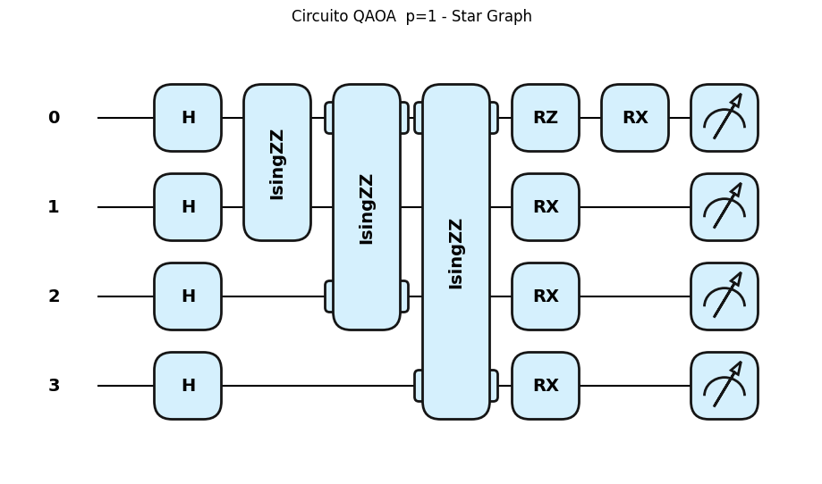

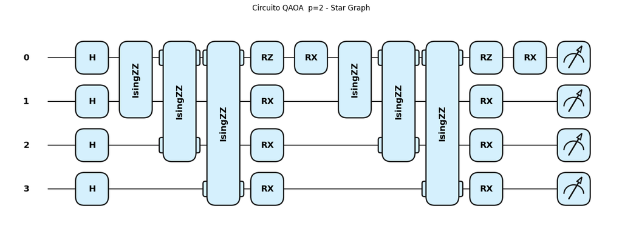

```python
G4c = nx.star_graph(3); G4c.graph["instance_id"] = 0
J4, h4, _ = qubo_to_ising(build_qubo(G4c))

for p_val in [1, 2]:
    dev_tmp = qml.device("default.qubit", wires=4)
    circ_tmp = make_qaoa(4, p_val, J4, h4, dev_tmp)
    fig, ax = qml.draw_mpl(circ_tmp, style="pennylane")(np.random.rand(2 * p_val))
    ax.set_title(f"Circuito QAOA  p={p_val} - Star Graph", fontsize=12)
    plt.tight_layout(); plt.show()
```

La differenza è evidente: con $p=2$ l'intero blocco IsingZZ → RZ → RX si ripete due volte, con parametri $(\gamma_1, \beta_1)$ nel primo strato e $(\gamma_2, \beta_2)$ nel secondo. COBYLA ha quindi il doppio dei parametri da ottimizzare: si guadagna una maggiore flessibilità nell'approssimare la soluzione ottima, ma il circuito è più profondo e ogni gate aggiuntivo è una fonte di errore su hardware reale.

### 3.2 Benchmark QAOA ($p = 1, 2, 3, 4, 5$)

Il benchmark esegue `run_qaoa` su tutte le combinazioni di dimensione, densità e profondità: 3 dimensioni × 20 istanze × 3 densità × 5 valori di `p` = 900 run totali. I risultati vengono salvati in `cache/qaoa.pkl` insieme alla configurazione usata: se i parametri cambiano, la cache viene invalidata e il benchmark riparte da zero.

```
Checkpoint caricato: 900 risultati QAOA
```

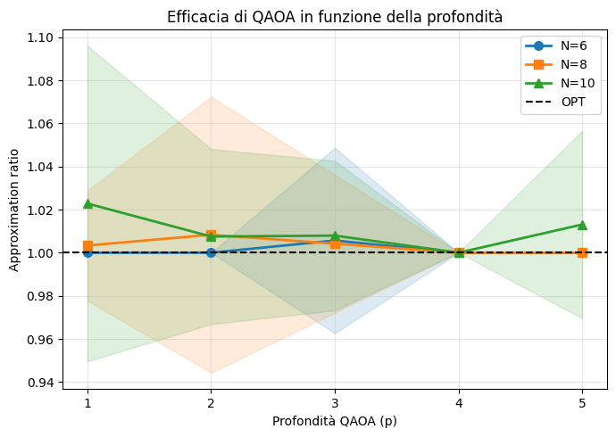

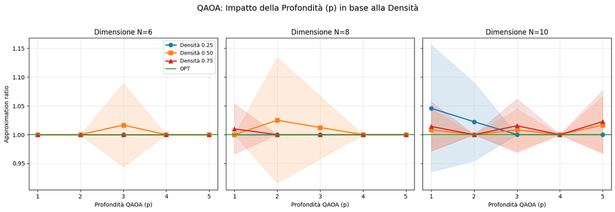

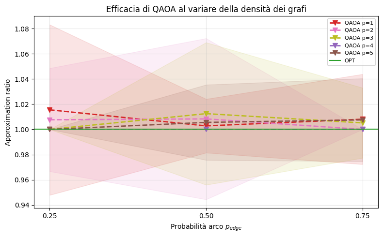

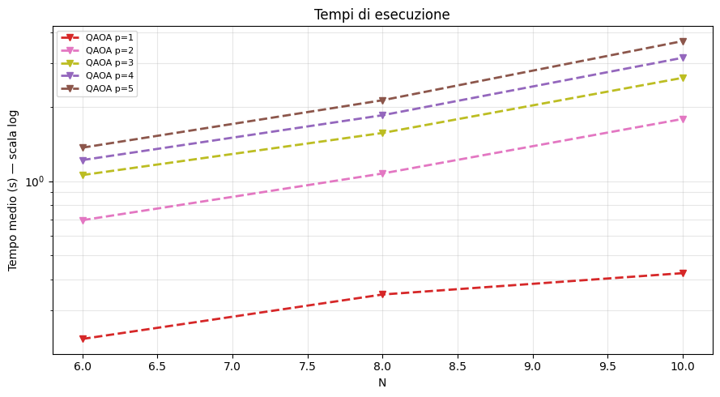

```
                                 Summary Table: QAOA
╔══════════════════════╤════════════╤════════════╤════════════╤════════════╤════════╗
║ Solver               │  Avg Ratio │  Std Ratio │  Max Ratio │  Avg t (s) │      n ║
╟──────────────────────┼────────────┼────────────┼────────────┼────────────┼────────╢
║ QAOA p=1             │     1.0088 │     0.0460 │     1.3333 │     0.3340 │    179 ║
║ QAOA p=2             │     1.0053 │     0.0441 │     1.5000 │     1.1839 │    179 ║
║ QAOA p=3             │     1.0059 │     0.0369 │     1.3333 │     1.7462 │    179 ║
║ QAOA p=4             │     1.0000 │     0.0000 │     1.0000 │     2.0717 │    179 ║
║ QAOA p=5             │     1.0044 │     0.0260 │     1.1667 │     2.3902 │    179 ║
╚══════════════════════╧════════════╧════════════╧════════════╧════════════╧════════╝
```

```python
CONFIG_QAOA = {
    "sizes":   SIZES,
    "n_inst":  N_INST,
    "edge_p":  EDGE_P,
    "p_list":  P_LIST,
    "max_iter": MAX_ITER,
}

if os.path.exists(CACHE_QAOA):
    cached = pickle.load(open(CACHE_QAOA, "rb"))
    if isinstance(cached, tuple) and len(cached) == 3 and cached[2] == CONFIG_QAOA:
        QAOA_RES, OPT_PARAMS = cached[0], cached[1]
        print(f"Checkpoint caricato: {len(QAOA_RES)} risultati QAOA")
    else:
        print("⚠️ Cache obsoleta o parametri cambiati. Ricalcolo in corso...")
        QAOA_RES = None
else:
    QAOA_RES = None

if QAOA_RES is None:
    QAOA_RES   = []
    OPT_PARAMS = {}
    opt_lookup = {(r.n, r.iid): r.sz for r in CLASSICAL if r.solver == "branch_and_bound"}

    for n in tqdm(SIZES, desc="Dimensioni QAOA"):
        for G in tqdm(ALL[n], desc=f"  N={n}", leave=False):
            iid = G.graph["instance_id"]
            opt = opt_lookup.get((n, iid), -1)
            for p in P_LIST:
                r, params, _, _ = run_qaoa(G, p=p, opt=opt)
                QAOA_RES.append(r); OPT_PARAMS[(n, iid, p)] = params

    pickle.dump((QAOA_RES, OPT_PARAMS, CONFIG_QAOA), open(CACHE_QAOA, "wb"))
    print(f"Benchmark QAOA completato: {len(QAOA_RES)} risultati — checkpoint salvato")


# ── qaoa_best: seleziona il miglior p per ogni (n, iid) ─────────────────
_best_by_inst = {}
for r in QAOA_RES:
    if not r.solver.startswith("qaoa_p"): continue
    key = (r.n, r.iid)
    if key not in _best_by_inst or r.ratio < _best_by_inst[key].ratio:
        _best_by_inst[key] = r

QAOA_RES = [r for r in QAOA_RES if r.solver != "qaoa_best"]

QAOA_BEST = [
    R("qaoa_best", r.n, r.iid, r.sz, r.opt, r.ratio, r.t, r.ok)
    for r in _best_by_inst.values()
]
QAOA_RES.extend(QAOA_BEST)


# ── Plot e Tabelle finali ──────────────────────────────────────────────
plot_qaoa_vs_p(QAOA_RES, SIZES, title="Efficacia di QAOA in funzione della profondità")
plot_qaoa_depth_vs_density(QAOA_RES, n_inst=N_INST, sizes=SIZES, edge_p_list=EDGE_P)
plot_ratio_vs_edge_p(
    QAOA_RES,
    n_inst=N_INST, edge_p_list=EDGE_P,
    title="Efficacia di QAOA al variare della densità dei grafi"
)
plot_time_vs_n(QAOA_RES)
print_summary_table(QAOA_RES, title="Summary Table: QAOA ")
```

I risultati mostrano che il comportamento di QAOA al crescere della profondità $p$ è non monotono: il ratio medio non cresce con $p$, ma oscilla tra ~$1.004$ e $1.009$ per $p = 1,2,3,5$, scendendo a $1.0000$ esatto a $p = 4$. Questo è da considerarsi come artefatto statistico, probabilmente dovuto al valore $1024$ assegnato a **N_SHOTS**.

| $p$ | Avg Ratio | Std Ratio | Max Ratio | Avg t (s) |
| --- | --- | --- | --- | --- |
| 1 | 1.0088 | 0.0460 | 1.3333 | 0.334 |
| 2 | 1.0053 | 0.0441 | 1.5000 | 1.184 |
| 3 | 1.0059 | 0.0369 | 1.3333 | 1.746 |
| 4 | **1.0000** | **0.0000** | **1.0000** | 2.072 |
| 5 | 1.0044 | 0.0260 | 1.1667 | 2.390 |

Il dato più informativo risulta essere la variabilità dei risultati più che il ratio medio, che è quasi identico per tutte le profondità. La deviazione standard tende a ridursi fino a p=4, dove si annulla, per poi risalire a 0.026 a p=5. Questo suggerisce che non sia una tendenza strutturale.

Un risultato interessante è che QAOA a $p=4$ trova la cover ottima in tutte le istanze considerate ($\text{std}=0$). Ciononostante, va osservato che il tempo medio di esecuzione è circa sei volte superiore a quello di $p=1$. Per questo motivo, nelle analisi comparative con i solver classici si utilizza la modalità best-$p$ per istanza, che rappresenta il limite superiore delle prestazioni ottenibili.

### 3.3 Convergenza COBYLA

Esaminiamo la fase di ottimizzazione dei parametri tramite COBYLA su tre istanze di riferimento ($N=8$, $\text{iid} = [0, 20, 40]$).

I cinque grafici mostrano la curva di convergenza per $p=1,...,5$. L'asse y è il valore atteso $\langle H_C\rangle$: più è basso, migliore è la soluzione.

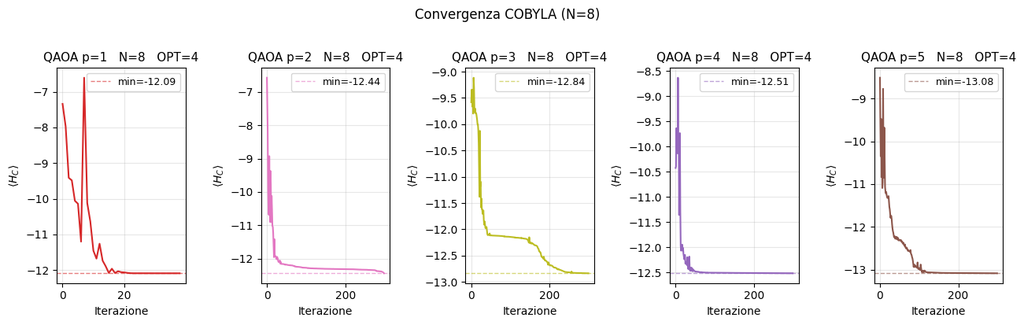

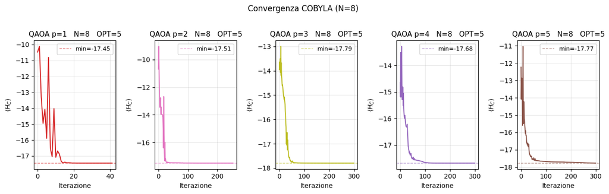

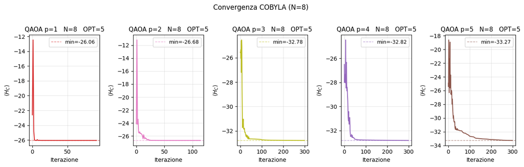

```python
REF_INSTANCES = [
    (ALL[8][0],  0,  "0.25"),
    (ALL[8][20], 20, "0.50"),
    (ALL[8][40], 40, "0.75"),
]

for G_ref, iid, label in REF_INSTANCES:
    opt_ref = next(r.sz for r in CLASSICAL
                   if r.solver == "branch_and_bound"
                   and r.n == 8 and r.iid == iid)

    energy_hists = {}
    for p_val in tqdm(P_LIST, desc=f"Convergenza (p_edge={label})"):
        _, _, hist, _ = run_qaoa(G_ref, p=p_val, opt=opt_ref,
                                 max_iter=300, n_shots=1024)
        energy_hists[p_val] = hist

    plot_cobyla_convergence(energy_hists, G_ref, opt_ref)
```

Possiamo osservare che il risultato è dipendente dall'istanza: la struttura del grafo influenza la forma della funzione di costo (valore atteso dell’energia) in funzione dei parametri di QAOA. Per questo motivo, una profondità maggiore non implica necessariamente una soluzione migliore. Si osserva invece in modo consistente un aumento delle iterazioni necessarie all'ottimizzazione, dovuto al maggior numero di parametri da esplorare.

La maggiore densità del grafo consente alla funzione obiettivo di raggiungere minimi più bassi. Nei grafi sparsi, al contrario, il numero ridotto di archi limita la scala energetica e rende meno evidenti le differenze tra le diverse profondità di QAOA.

### 3.4 Distribuzione probabilistica $|\psi_p\rangle$

Una volta ottimizzati i parametri $(\gamma, \beta)$, il circuito QAOA produce uno stato $|\psi_p\rangle$: una sovrapposizione di tutti i $2^N$ bitstring possibili, ciascuno corrispondente a un candidato vertex cover. Misurare il circuito equivale a campionare da questa distribuzione.

Il seguente grafico mostra questa distribuzione per $p=1,...,5$ sull'istanza di riferimento ($N=8$, $\text{iid}=[0, 20, 40]$), con 1024 shots per profondità. Ogni barra è colorata in base alla qualità della cover: verde se ottima, blu se valida ma sovradimensionata, rosso se non valida.

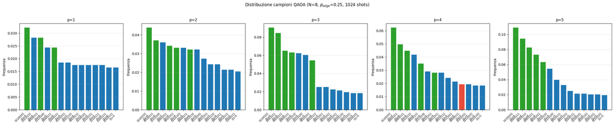

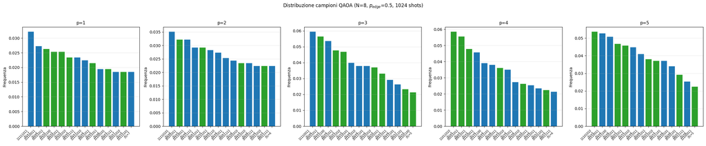

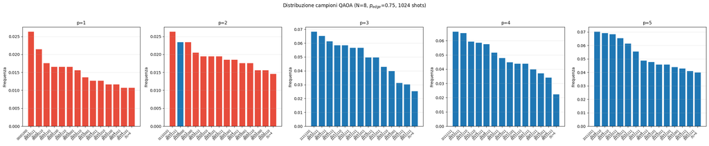

```python
for iid, edge_p in [(0, 0.25), (20, 0.50), (40, 0.75)]:
    G_dist = ALL[8][iid]
    opt_d  = next(r.sz for r in CLASSICAL
                  if r.solver == "branch_and_bound"
                  and r.n == 8 and r.iid == iid)   # iid coerente con G_dist
    fig, axes = plt.subplots(1, 5, figsize=(25, 5))
    for ax, p_val in zip(axes, P_LIST):
        _, _, _, counts = run_qaoa(G_dist, p=p_val, opt=opt_d,
                                   max_iter=300, n_shots=1024)
        plot_bitstring_distribution(G_dist, counts, opt_d,
                                    title=f"p={p_val}", n_shots=1024, ax=ax)
    plt.suptitle(f"Distribuzione campioni QAOA (N=8, $p_{{edge}}$={edge_p}, 1024 shots)",
                 fontsize=12, y=1.02)
    plt.tight_layout(); plt.show()
```

Le distribuzioni dei bitstring cambiano sensibilmente al variare della densità del grafo.

- Per i grafi a densità 0.25, le soluzioni ottime compaiono già a $p=1$ e diventano progressivamente più frequenti all'aumentare di $p$. In questo regime, anche circuiti poco profondi riescono a concentrare una parte significativa della probabilità sulle cover ottime.
- Per i grafi a densità 0.50, le cover ottime sono presenti a tutte le profondità, ma convivono con altre cover valide. L'aumento del numero di archi rende la distinzione tra soluzioni ottime e quasi ottime meno netta, pur mantenendo una buona probabilità di osservare l'ottimo.
- Nei grafi a densità 0.75, il comportamento cambia in modo evidente. Per $p=1$ e $p=2$ prevalgono soluzioni non valide, segno che il circuito non è sufficientemente espressivo. A partire da $p=3$ vengono prodotte quasi esclusivamente cover valide, ma la probabilità si distribuisce tra molte soluzioni quasi ottime e non si concentra sulla cover minima.

Nel complesso, i grafi a densità intermedia ($p_\text{edge}=0.5$) rappresentano il caso più informativo: le soluzioni ottime sono osservabili con probabilità apprezzabile e le differenze tra le varie profondità risultano chiaramente distinguibili, motivo per cui, verranno impiegate nei prossimi benchmark.

### 3.5 Rumore Depolarizing (PennyLane)

Nelle sezioni precedenti i parametri sono stati ottimizzati su circuiti ideali. In un contesto reale, ogni gate introduce errori fisici: un qubit può essere ruotato accidentalmente, perdendo l'informazione di fase su cui QAOA si basa. Il modello più semplice per catturare questo effetto è il **canale depolarizing**: con probabilità $p$ il qubit subisce una rotazione casuale uniforme su X, Y o Z; con probabilità $1-p$ rimane invariato. $$\mathcal{E}(\rho) = (1-p)\,\rho + \frac{p}{3}\bigl(X\rho X + Y\rho Y + Z\rho Z\bigr)$$ Dove $\rho$ è lo stato del qubit prima del gate, $\mathcal{E}(\rho)$ è lo stato risultante dopo il rumore, e $X$, $Y$, $Z$ sono le matrici di Pauli. Con probabilità $1-p$ il qubit rimane invariato, con probabilità $\frac{p}{3}$ ciascuno subisce una rotazione casuale su uno dei tre assi.

L’analisi che segue valuta il degrado delle prestazioni al crescere della profondità $p$, mantenendo fissi i parametri ($\gamma$, $\beta$) già ottimizzati in assenza di rumore. Questa scelta è intenzionale: consente di isolare l’effetto del rumore dalla fase di ottimizzazione, evidenziando quanto la soluzione sia robusta a perturbazioni fisiche non considerate durante il training.

```
Checkpoint caricato
checkpoint salvato
```

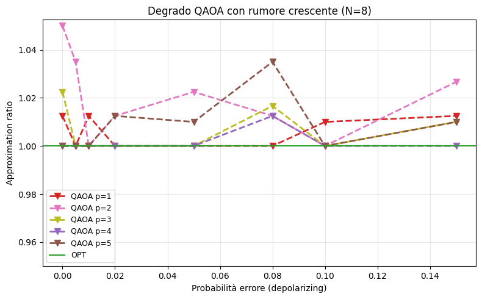

```python
CACHE_SWEEP = "data/cache_noise_sweep.pkl"
CONFIG_SWEEP = {
    "p_list": P_LIST,
    "noise_levels": NOISE_LEVELS,
    "grafi": [G.graph["instance_id"] for G in ALL[8][20:40]]
}

cached = load_cache(CACHE_SWEEP, CONFIG_SWEEP)
if cached is not None:
    SWEEP_AVG, sweep_counts_by_prob, G_noise, opt_n = cached
    print("Checkpoint caricato")
else:
    grafi_d2 = ALL[8][20:40]
    opt_lookup = {(r.n, r.iid): r.sz for r in CLASSICAL if r.solver == "branch_and_bound"}

    sweep_ratios = {p: {prob: [] for prob in NOISE_LEVELS} for p in P_LIST}
    sweep_counts_by_prob = {f"Noise {prob}": {} for prob in NOISE_LEVELS}

    for G_noise in tqdm(grafi_d2, desc="PennyLane Noise Sweep (20 grafi)"):
        iid = G_noise.graph["instance_id"]
        opt_n = opt_lookup.get((8, iid), -1)

        n_n = G_noise.number_of_nodes()
        J_n, h_n, _ = qubo_to_ising(build_qubo(G_noise))

        for p_val in P_LIST:
            params = OPT_PARAMS.get((8, iid, p_val))
            if params is None: continue

            for prob in NOISE_LEVELS:
                dtype = "default.mixed" if prob > 0 else "default.qubit"
                dev_s = qml.device(dtype, wires=n_n, shots=1024)
                samp  = make_sampler(n_n, p_val, J_n, h_n, dev_s, noisy=(prob > 0), noise_prob=prob)

                counts = _samples_to_counts(samp(params))
                cov    = _best_cover(G_noise, counts)

                ratio = len(cov) / opt_n if opt_n > 0 else -1
                sweep_ratios[p_val][prob].append(ratio)

                # Sovrascrive i counts: alla fine rimarranno quelli dell'ultimo grafo!
                sweep_counts_by_prob[f"Noise {prob}"][p_val] = counts


    # --- PLOT MEDIO (su 20 grafi) ---
    SWEEP_AVG = {}
    for p_val in P_LIST:
        SWEEP_AVG[p_val] = []
        for prob in NOISE_LEVELS:
            SWEEP_AVG[p_val].append({
                "prob":  prob,
                "sz":    0,
                "ratio": np.mean(sweep_ratios[p_val][prob]),
            })

save_cache(CACHE_SWEEP, CONFIG_SWEEP, SWEEP_AVG, sweep_counts_by_prob, G_noise, opt_n)
print("checkpoint salvato")

plot_noise_sweep(SWEEP_AVG, n_val=8)
```

$p=4$ sembra essere la configurazione più stabile: parte da 1.000 e vi rimane per la maggior parte dell'intervallo, confermando la robustezza già osservata nel benchmark. $p=2$ mostra invece la varianza più alta: l'ottimizzatore converge verso minimi locali su alcune istanze, e anche un rumore minimo è sufficiente a perturbare la distribuzione.

Per essere sicuri dell'ottimalità di $p=4$, procediamo nell'analisi della probabilità dell'ottimo:

```python
print_p_opt_summary(
    configs=sweep_counts_by_prob,
    G=G_noise,
    opt=opt_n,
    p_list=P_LIST,
    n_shots=1024,
    sort_by_p_opt=False
)
```

```
            Probabilità Ottimo (p=1)                         Probabilità Ottimo (p=2)                         Probabilità Ottimo (p=3)                         Probabilità Ottimo (p=4)                         Probabilità Ottimo (p=5)

  Configurazione    p_opt   Shot ottimi / 1024     Configurazione    p_opt   Shot ottimi / 1024     Configurazione    p_opt   Shot ottimi / 1024     Configurazione    p_opt   Shot ottimi / 1024     Configurazione    p_opt   Shot ottimi / 1024
 ──────────────────────────────────────────────   ──────────────────────────────────────────────   ──────────────────────────────────────────────   ──────────────────────────────────────────────   ──────────────────────────────────────────────
  Noise 0.0        0.0107                  ~11     Noise 0.0        0.0117                  ~12     Noise 0.0        0.0225                  ~23     Noise 0.0        0.0391                  ~40     Noise 0.0        0.0967                  ~99
  Noise 0.005      0.0156                  ~16     Noise 0.005      0.0146                  ~15     Noise 0.005      0.0146                  ~15     Noise 0.005      0.0264                  ~27     Noise 0.005      0.0566                  ~58
  Noise 0.01       0.0078                   ~8     Noise 0.01       0.0098                  ~10     Noise 0.01       0.0156                  ~16     Noise 0.01       0.0264                  ~27     Noise 0.01       0.0342                  ~35
  Noise 0.02       0.0078                   ~8     Noise 0.02       0.0068                   ~7     Noise 0.02       0.0107                  ~11     Noise 0.02       0.0166                  ~17     Noise 0.02       0.0195                  ~20
  Noise 0.05       0.0068                   ~7     Noise 0.05       0.0068                   ~7     Noise 0.05       0.0068                   ~7     Noise 0.05       0.0039                   ~4     Noise 0.05       0.0049                   ~5
  Noise 0.08       0.0059                   ~6     Noise 0.08       0.0039                   ~4     Noise 0.08       0.0020                   ~2     Noise 0.08       0.0029                   ~3     Noise 0.08       0.0029                   ~3
  Noise 0.1        0.0029                   ~3     Noise 0.1        0.0039                   ~4     Noise 0.1        0.0029                   ~3     Noise 0.1        0.0020                   ~2     Noise 0.1        0.0010                   ~1
  Noise 0.15       0.0029                   ~3     Noise 0.15       0.0000                   ~0     Noise 0.15       0.0010                   ~1     Noise 0.15       0.0020                   ~2     Noise 0.15       0.0010                   ~1
```

L’analisi della metrica $p_{opt}$ evidenzia in modo più marcato la dinamica del QAOA rispetto all’approximation ratio, mostrando come la probabilità di osservare la soluzione ottima vari significativamente con la profondità $p$ e con il livello di rumore.

In assenza di rumore, $p_\text{opt}$ cresce monotonicamente con $p$, indicando che circuiti più profondi concentrano meglio la probabilità sulle soluzioni ottime. Questo rovescia il quadro dell'approximation ratio, dove il miglioramento con $p$ era mascherato dal fatto che _best_cover trova l'ottimo anche quando compare raramente.

Con il rumore, la gerarchia si inverte progressivamente: $p=5$ degrada più rapidamente di tutti, mentre $p=1$ e $p=2$ perdono meno in termini relativi, pur partendo da valori più bassi. $p=2$ è l'unica configurazione che azzera completamente $p_\text{opt}$ ad alto rumore.

### 3.6 Qiskit Aer

Il canale depolarizing della sezione precedente è un modello omogeneo: ogni qubit e ogni gate hanno lo stesso tasso di errore. Su un chip reale questo non accade: ogni qubit è un oscillatore fisico con caratteristiche proprie, soggetto a diverse fonti di rumore con origine fisica distinta.

In particolare, le principali fonti di rumore nei dispositivi quantistici sono tre. Il tempo di rilassamento $T_1$ descrive la perdita spontanea di energia, per cui lo stato $|1\rangle$ tende a decadere verso $|0\rangle$ durante l’esecuzione del circuito. Il tempo di decoerenza $T_2$ descrive la perdita della coerenza nelle sovrapposizioni quantistiche. In altri termini, l’interferenza scompare e il comportamento del sistema diventa progressivamente classico. Infine, il readout error introduce imprecisioni nella fase di misura, causando una possibile errata identificazione degli stati $|0\rangle$ e $|1\rangle$. Inoltre, i gate a due qubit hanno tassi di errore $10–100$ volte superiori ai gate a singolo qubit, e variano da coppia a coppia a seconda della qualità del collegamento fisico.

`GenericBackendV2` di Qiskit incorpora tutti e tre gli effetti con parametri tipici di un dispositivo IBM, rendendo la simulazione molto più fedele di un semplice canale depolarizing.

Il circuito QAOA è identico: stessi gate ($H$, $R_{ZZ}$, $R_Z$, $R_X$), stessa struttura a layer, stessi parametri $(\boldsymbol{\gamma}, \boldsymbol{\beta})$. Tuttavia, ci sono alcune considerazioni da fare:

1. La pipeline PennyLane comprendeva `make_qaoa` e `make_sampler`. Qui esiste solo `sample_aer`: i parametri ottimali sono quelli già trovati da PennyLane e salvati in `OPT_PARAMS`. Questo è intenzionale, poichè si vogliono confrontare i due simulatori di rumore, non due ottimizzatori.
2. PennyLane gestisce internamente la decomposizione dei gate. In Qiskit invece, bisogna eseguire un ulteriore passaggio: `transpile(qc, sim, optimization_level=1)` converte il gate $R_{ZZ}$ nel gate set nativo IBM. Questo è necessario perché il noise model è definito sui gate fisici del dispositivo, quindi applicarlo prima della decomposizione porterebbe a risultati non corretti.
3. In PennyLane il flag `noisy=True/False` riconfigura direttamente il device. In Qiskit, il flag esiste ancora, ma internamente seleziona tra due simulatori: `_sim_hw` (noise model da `GenericBackendV2`) e `_sim_ideal` (nessun rumore). Il confronto tra i due isola l'effetto del rumore hardware a parità di circuito e parametri.
4. Qiskit restituisce i bitstring come stringhe con i bit in ordine invertito rispetto alla convenzione interna del notebook. `_norm_counts` corregge questo, estraendo gli ultimi $n$ bit e convertendoli in tuple compatibili con il resto del codice.

```python
from qiskit.providers.fake_provider import GenericBackendV2
from qiskit_aer.noise import NoiseModel
from qiskit_aer import AerSimulator
from qiskit import QuantumCircuit, transpile

_backend = GenericBackendV2(num_qubits=max(SIZES), seed=GLOBAL_SEED)
_nm        = NoiseModel.from_backend(_backend)
_sim_hw    = AerSimulator(noise_model=_nm)
_sim_ideal = AerSimulator()

print(f"Backend: {_backend.name}")
print(f"Basis gates: {_nm.basis_gates}")

def build_qaoa_qiskit(n, p, J, h, gammas, betas):
    """Circuito QAOA in gate nativi IBM (rzz → CX+RZ via transpile)."""
    qc = QuantumCircuit(n)
    for i in range(n): qc.h(i)
    for layer in range(p):
        g, b = gammas[layer], betas[layer]
        for i in range(n):
            for j in range(i+1, n):
                if abs(J[i,j]) > 1e-10: qc.rzz(2*g*J[i,j], i, j)
        for i in range(n):
            if abs(h[i]) > 1e-10: qc.rz(2*g*h[i], i)
        for i in range(n): qc.rx(2*b, i)
    qc.measure_all()
    return qc

def _norm_counts(raw, n):
    counts = {}
    for bitstr, cnt in raw.items():
        key = tuple(int(b) for b in bitstr.replace(" ", "")[-n:][::-1])
        counts[key] = counts.get(key, 0) + cnt
    return counts

def sample_aer(G, p, opt_params, n_shots=N_SHOTS, noisy=True, seed=GLOBAL_SEED):
    """Campiona QAOA tramite Qiskit Aer (ideale o hw-noise)."""
    n = G.number_of_nodes()
    J, h, _ = qubo_to_ising(build_qubo(G))
    qc  = build_qaoa_qiskit(n, p, J, h, opt_params[:p], opt_params[p:])
    sim = _sim_hw if noisy else _sim_ideal
    qct = transpile(qc, sim, optimization_level=1)
    raw = sim.run(qct, shots=n_shots, seed_simulator=seed).result().get_counts()
    counts = _norm_counts(raw, n)
    return _best_cover(G, counts), counts

print("Funzioni Qiskit Aer definite ✓")
```

```
Backend: generic_backend_10q
Basis gates: ['cx', 'delay', 'id', 'measure', 'reset', 'rz', 'sx', 'x']
Funzioni Qiskit Aer definite ✓
```

Il seguente blocco esegue il benchmark Aer con la stessa struttura già usata per PennyLane: per ogni combinazione $(N, \text{iid}, p)$.

`sample_aer` viene chiamato due volte: una con `noisy=False` e una con `noisy=True`. I risultati vengono salvati in un dizionario, pronti per il confronto.

[output not shown]

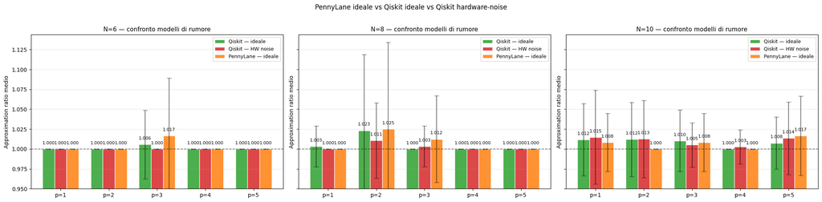

```
                             PennyLane ideale vs Qiskit ideale vs Qiskit HW-noise
╭──────┬──────┬───────┬─────────────┬───────────────┬─────────────┬──────────────┬─────────────┬──────────────╮
│    N │    p │   OPT │   PL ideale │  Qiskit ideal │   Qiskit HW │ Δ (Ideal−PL) │   Δ (HW−PL) │ Δ (HW−Ideal) │
├──────┼──────┼───────┼─────────────┼───────────────┼─────────────┼──────────────┼─────────────┼──────────────┤
│    6 │    1 │     2 │      1.0000 │        1.0000 │      1.0000 │      +0.0000 │     +0.0000 │      +0.0000 │
│    6 │    2 │     2 │      1.0000 │        1.0000 │      1.0000 │      +0.0000 │     +0.0000 │      +0.0000 │
│    6 │    3 │     2 │      1.0167 │        1.0056 │      1.0000 │      -0.0110 │     -0.0167 │      -0.0056 │
│    6 │    4 │     2 │      1.0000 │        1.0000 │      1.0000 │      +0.0000 │     +0.0000 │      +0.0000 │
│    6 │    5 │     2 │      1.0000 │        1.0000 │      1.0000 │      +0.0000 │     +0.0000 │      +0.0000 │
│    8 │    1 │     4 │      1.0000 │        1.0033 │      1.0000 │      +0.0033 │     +0.0000 │      -0.0033 │
│    8 │    2 │     4 │      1.0250 │        1.0233 │      1.0108 │      -0.0017 │     -0.0142 │      -0.0125 │
│    8 │    3 │     4 │      1.0125 │        1.0000 │      1.0033 │      -0.0125 │     -0.0092 │      +0.0033 │
│    8 │    4 │     4 │      1.0000 │        1.0000 │      1.0000 │      +0.0000 │     +0.0000 │      +0.0000 │
│    8 │    5 │     4 │      1.0000 │        1.0000 │      1.0000 │      +0.0000 │     +0.0000 │      +0.0000 │
│   10 │    1 │     4 │      1.0083 │        1.0117 │      1.0149 │      +0.0034 │     +0.0065 │      +0.0032 │
│   10 │    2 │     4 │      1.0000 │        1.0121 │      1.0127 │      +0.0121 │     +0.0127 │      +0.0006 │
│   10 │    3 │     4 │      1.0083 │        1.0103 │      1.0052 │      +0.0020 │     -0.0032 │      -0.0052 │
│   10 │    4 │     4 │      1.0000 │        1.0000 │      1.0028 │      +0.0000 │     +0.0028 │      +0.0028 │
│   10 │    5 │     4 │      1.0167 │        1.0075 │      1.0137 │      -0.0091 │     -0.0030 │      +0.0061 │
╰──────┴──────┴───────┴─────────────┴───────────────┴─────────────┴──────────────┴─────────────┴──────────────╯
```

```python
CONFIG_AER = {
    "sizes":   SIZES,
    "n_inst":  N_INST,
    "p_list":  P_LIST,
    "edge_p":  EDGE_P,
}

if os.path.exists(CACHE_AER):
    cached = pickle.load(open(CACHE_AER, "rb"))
    if isinstance(cached, tuple) and len(cached) == 2 and cached[1] == CONFIG_AER:
        AER_RES = cached[0]
        print(f"Checkpoint caricato: {len(AER_RES)} risultati Aer")
    else:
        print("⚠️ Cache obsoleta o parametri cambiati. Ricalcolo in corso...")
        AER_RES = None
else:
    AER_RES = None

if AER_RES is None:
    AER_RES = []
    opt_lookup = {(r.n, r.iid): r.sz for r in CLASSICAL if r.solver == "branch_and_bound"}

    for n_val in tqdm(SIZES, desc="Aer benchmark"):
        for G in tqdm(ALL[n_val][20:40], desc=f"  N={n_val}", leave=False):
            iid = G.graph["instance_id"]
            opt = opt_lookup.get((n_val, iid), -1)

            for p_val in P_LIST:
                params = OPT_PARAMS.get((n_val, iid, p_val))
                if params is None:
                    continue

                # Simulazione Qiskit Ideale
                cov_i, _ = sample_aer(G, p_val, params, noisy=False)
                # Simulazione Qiskit HW-noise
                cov_h, _ = sample_aer(G, p_val, params, noisy=True)

                si, sh = len(cov_i), len(cov_h)

                AER_RES.append({
                    "n": n_val, "iid": iid, "p": p_val, "opt": opt,
                    "sz_ideal": si, "ratio_ideal": si/opt if opt > 0 else -1,
                    "sz_hw":    sh, "ratio_hw":    sh/opt if opt > 0 else -1
                })

    pickle.dump((AER_RES, CONFIG_AER), open(CACHE_AER, "wb"))
    print(f"Aer benchmark completato: {len(AER_RES)} entry — checkpoint salvato")


QAOA_RES_D2 = [r for r in QAOA_RES if 20 <= r.iid < 40]
plot_aer_vs_pl_bars(QAOA_RES_D2, AER_RES, SIZES, P_LIST)
print_aer_comparison_table(QAOA_RES_D2, AER_RES, SIZES, P_LIST)
```

Dalla tabella emergono due osservazioni principali.

1. Gli scarti tra Qiskit HW-noise e Qiskit ideale sono prossimi allo zero a ogni profondità: sulla metrica dell'approximation ratio, il rumore hardware-calibrato di Aer non degrada quasi per niente la qualità della soluzione restituita. Questo succede perché `_best_cover` seleziona la cover migliore tra i 1024 shots, ed è sufficiente che l'ottimo compaia anche raramente perché il ratio resti $\approx 1$.
2. Anche lo scarto tra Qiskit ideale e PennyLane ideale è trascurabile, a conferma che le due pipeline implementano lo stesso circuito a parità di parametri: le piccole differenze residue sono attribuibili al campionamento (cioè ai 1024 shot) e, in misura minore, alla transpilazione nei gate nativi.

La conseguenza è che il ratio, su queste istanze, è una metrica poco discriminante. È la distribuzione completa dei bitstring a rendere visibili gli effetti del rumore che il ratio nasconde.

Prima di scegliere la configurazione di riferimento, ripetiamo l'analisi già fatta per PennyLane: la distribuzione dei bitstring per ogni profondità $p$.

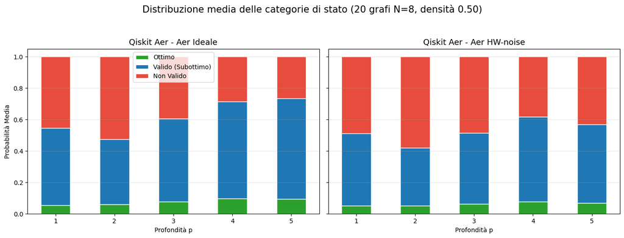

```
     p_opt Medio (p=1)           p_opt Medio (p=2)           p_opt Medio (p=3)           p_opt Medio (p=4)           p_opt Medio (p=5)

  Configurazione    p_opt     Configurazione    p_opt     Configurazione    p_opt     Configurazione    p_opt     Configurazione    p_opt
 ─────────────────────────   ─────────────────────────   ─────────────────────────   ─────────────────────────   ─────────────────────────
  Aer Ideale       0.0536     Aer Ideale       0.0604     Aer Ideale       0.0787     Aer Ideale       0.0988     Aer Ideale       0.0943
  Aer HW-noise     0.0525     Aer HW-noise     0.0518     Aer HW-noise     0.0637     Aer HW-noise     0.0766     Aer HW-noise     0.0683
```

```python
REF_INSTANCES = [(ALL[8][i], i, "0.50") for i in range(20, 40)]

stats = {
    p_val: {
        "Aer Ideale":   {"opt": [], "val": [], "inv": []},
        "Aer HW-noise": {"opt": [], "val": [], "inv": []}
    }
    for p_val in P_LIST
}

for G_d2, iid, label in tqdm(REF_INSTANCES, desc="Campionamento istanze"):

    opt_d2 = next(r.sz for r in CLASSICAL
                  if r.solver == "branch_and_bound" and r.n == 8 and r.iid == iid)

    nodes = list(G_d2.nodes())

    for p_val in P_LIST:
        params = OPT_PARAMS.get((8, iid, p_val))
        if params is None:
            continue

        _, ci = sample_aer(G_d2, p_val, params, n_shots=1024, noisy=False)
        _, ch = sample_aer(G_d2, p_val, params, n_shots=1024, noisy=True)

        opt_i, val_i, inv_i = calc_probs(G_d2, nodes, opt_d2, ci)
        opt_h, val_h, inv_h = calc_probs(G_d2, nodes, opt_d2, ch)

        stats[p_val]["Aer Ideale"]["opt"].append(opt_i)
        stats[p_val]["Aer Ideale"]["val"].append(val_i)
        stats[p_val]["Aer Ideale"]["inv"].append(inv_i)

        stats[p_val]["Aer HW-noise"]["opt"].append(opt_h)
        stats[p_val]["Aer HW-noise"]["val"].append(val_h)
        stats[p_val]["Aer HW-noise"]["inv"].append(inv_h)

_disp.plot_state_categories_stacked(stats, P_LIST)
_disp.print_p_opt_average_table(stats, P_LIST)
```

L'analisi mediata su 20 istanze ($p_\text{edge}=0.5$, $N=8$) conferma i trend già osservati: tipicamente, l'aumentare della profondità migliora la qualità delle soluzioni, e il risultato migliore si ottiene per $p=4$ in entrambe le configurazioni (ideale e HW-noise).

## 4. Applicazione QAOA su HW Quantistico Reale

Le sezioni precedenti hanno lavorato interamente su simulatori. Questa sezione esegue QAOA su un processore superconduttore IBM reale, tramite `qiskit-ibm-runtime`.

I parametri $(\gamma^*, \beta^*)$ sono ottimizzati sul simulatore ideale e successivamente trasferiti invariati all’hardware reale. Questa scelta non è mossa solamente dai vincoli di quota (l'ottimizzazione su IBM comporterebbe un alto costo computazionale in termini di job e tempo di esecuzione), ma riflette anche lo scenario reale di utilizzo, in cui l’ottimizzazione viene effettuata su un simulatore e il circuito viene poi eseguito su hardware. Il confronto ottenuto misura quindi il degrado prestazionale dal caso ideale al dispositivo reale.

$$\text{degrado reale} = \text{ratio}_{\text{IBM}} - \text{ratio}_{\text{ideale}}$$

Valori positivi indicano che il rumore fisico peggiora la soluzione rispetto alla simulazione ideale. Confrontando questo valore con il degrado già misurato su Aer si valuta quanto il noise model hardware-calibrato sia predittivo del comportamento reale.

```python
try:
    from qiskit_ibm_runtime import QiskitRuntimeService, SamplerV2 as Sampler
    from qiskit.transpiler.preset_passmanagers import generate_preset_pass_manager
    _IBM_AVAILABLE = True
    print("qiskit-ibm-runtime disponibile ✓")
except ImportError:
    _IBM_AVAILABLE = False
    print("qiskit-ibm-runtime non installato  →  pip install qiskit-ibm-runtime")
```

```
qiskit-ibm-runtime disponibile ✓
```

Tramite il seguente blocco di codice ci si connette al cloud IBM Quantum e si interrogano i backend disponibili, filtrando quelli operativi con almeno 8 qubit, così da poter eseguire il circuito sull'istanza $N=8$ usata nei benchmark eseguiti in precedenza. In output vengono mostrati nome, numero di qubit e numero di job in coda: quest'ultimo è il criterio di selezione, al fine di ridurre al minimo il tempo di attesa per l'esecuzione.

```python
IBM_SERVICE = None

if _IBM_AVAILABLE:
    try:
        IBM_SERVICE = QiskitRuntimeService(
            channel="ibm_quantum_platform",
            token=IBM_API_KEY,
        )
        print("Connessione IBM Quantum ✓")
        backends = IBM_SERVICE.backends(operational=True, min_num_qubits=8)
        print(f"\n{'Backend':<25} {'Qubit':>8} {'Pending jobs':>13}")
        print("-" * 46)
        for b in sorted(backends, key=lambda x: x.num_qubits):
            st = b.status()
            print(f"{b.name:<25} {b.num_qubits:>8} {st.pending_jobs:>13}")
    except Exception as e:
        print(f"Connessione fallita: {e}")
```

[output not shown]

```
Connessione IBM Quantum ✓

Backend                      Qubit  Pending jobs
----------------------------------------------
ibm_fez                        156             0
ibm_marrakesh                  156             0
ibm_kingston                   156             2
```

### 4.1 Implementazione con SamplerV2

La funzione `run_qaoa_ibm` definisce la seguente pipeline:

1. Costruzione del circuito QAOA con i parametri ottimali, che sono già noti
2. Selezione del backend meno occupato con almeno $n+1$ qubit (per lasciare un margine sulla topologia del chip)
3. Transpilazione del circuito in forma ISA tramite `generate_preset_pass_manager`: i gate logici (`rzz`, `rx`, `rz`) vengono tradotti nel gate set nativo IBM (CX, RZ, SX, X), aggiungendo gate SWAP dove la topologia del chip lo richiede. Il circuito risultante è più profondo — ogni gate astratto diventa una sequenza di gate fisici, e ogni gate fisico in più accumula rumore.
4. Sottomissione del job tramite SamplerV2, che è la primitiva moderna di Qiskit, e attende il risultato
5. Decodifica dei bitstring, estrazione della cover migliore e calcolo di due metriche: il ratio e $p_\text{opt}$, ovvero la frazione di shot che hanno prodotto esattamente la cover ottima.

```python
def run_qaoa_ibm(G, p, opt_params, service, n_shots=N_SHOTS, opt=-1,
                 prefer_backend=None, optimization_level=1, verbose=True):
    """Esegue QAOA su IBM hardware reale con SamplerV2."""
    n = G.number_of_nodes()
    J, h, _ = qubo_to_ising(build_qubo(G))
    qc = build_qaoa_qiskit(n, p, J, h, opt_params[:p], opt_params[p:])

    backend = (service.backend(prefer_backend) if prefer_backend
               else service.least_busy(operational=True, simulator=False,
                                       min_num_qubits=n+1))
    if verbose: print(f"Backend: {backend.name}  ({backend.num_qubits} qubit)")

    pm     = generate_preset_pass_manager(backend=backend,
                                          optimization_level=optimization_level)
    isa_qc = pm.run(qc)
    if verbose:
        print(f"Circuito ISA: profondità={isa_qc.depth()}, gate={isa_qc.count_ops()}")

    sampler = Sampler(backend)
    t0      = time.perf_counter()
    if verbose: print(f"Job in coda... (shots={n_shots})")
    job     = sampler.run([isa_qc], shots=n_shots)
    if verbose: print(f"Job ID: {job.job_id()}")

    result  = job.result(); elapsed = time.perf_counter() - t0
    if verbose: print(f"Completato in {elapsed:.1f}s")

    counts = _norm_counts(result[0].data.meas.get_counts(), n)
    cov    = _best_cover(G, counts); sz = len(cov)
    nodes  = list(G.nodes()); total = sum(counts.values())
    p_opt  = sum(v for bs, v in counts.items()
                 if valid(G, {nodes[i] for i,b in enumerate(bs) if b})
                 and sum(bs) == opt) / total if total else 0.0

    return {"job_id": job.job_id(), "backend": backend.name, "elapsed": elapsed,
            "sz": sz, "opt": opt, "ratio": sz/opt if opt>0 else -1,
            "ok": valid(G, cov), "counts": counts, "p_opt": p_opt}

print("run_qaoa_ibm definita ✓")
```

```
run_qaoa_ibm definita ✓
```

Per rispettare i vincoli di quota, il benchmark su hardware IBM viene ristretto a un sottoinsieme minimo di configurazioni:

```python
IBM_P_LIST = [1, 2]
IBM_N      = 8
IBM_IID    = 20

CONFIG_IBM = {"n": IBM_N, "iid": IBM_IID, "p_list": IBM_P_LIST}

if os.path.exists(CACHE_IBM):
    cached = pickle.load(open(CACHE_IBM, "rb"))
    if isinstance(cached, tuple) and cached[1] == CONFIG_IBM:
        IBM_RES = cached[0]
        print(f"Checkpoint caricato: {len(IBM_RES)} risultati IBM")
    else:
        print("⚠️ Cache obsoleta (iid cambiato) — ricalcolo")
        IBM_RES = []
else:
    IBM_RES = []

done_p = {r["p"] for r in IBM_RES}

if IBM_SERVICE is not None:
    G_ibm   = ALL[IBM_N][IBM_IID]
    opt_ibm = next(r.sz for r in CLASSICAL
                   if r.solver == "branch_and_bound"
                   and r.n == IBM_N and r.iid == IBM_IID)

    for p_val in tqdm(IBM_P_LIST, desc="Job IBM"):
        if p_val in done_p:
            print(f"p={p_val} già completato — skip"); continue
        params = OPT_PARAMS.get((IBM_N, IBM_IID, p_val))
        if params is None: continue
        try:
            res = run_qaoa_ibm(
                G=G_ibm, p=p_val, opt_params=params,
                service=IBM_SERVICE, n_shots=1024,
                opt=opt_ibm, verbose=True,
            )
            IBM_RES.append({"n": IBM_N, "iid": IBM_IID, "p": p_val, **res})
            pickle.dump((IBM_RES, CONFIG_IBM), open(CACHE_IBM, "wb"))
            print(f"  backend={res['backend']}  cover={res['sz']}  OPT={opt_ibm}  "
                  f"ratio={res['ratio']:.3f}  p_opt={res['p_opt']:.3f}")
        except Exception as e:
            print(f"  Errore p={p_val}: {e}")
else:
    print("IBM Quantum non configurato — sezione saltata.")
```

```
Checkpoint caricato: 2 risultati IBM
```

```
p=1 già completato — skip
p=2 già completato — skip
```

Mostriamo i risultati, paragonandoli a quelli ottenuti dai framework PennyLane e Qiskit Aer, sia in presenza di rumore che in sua assenza.

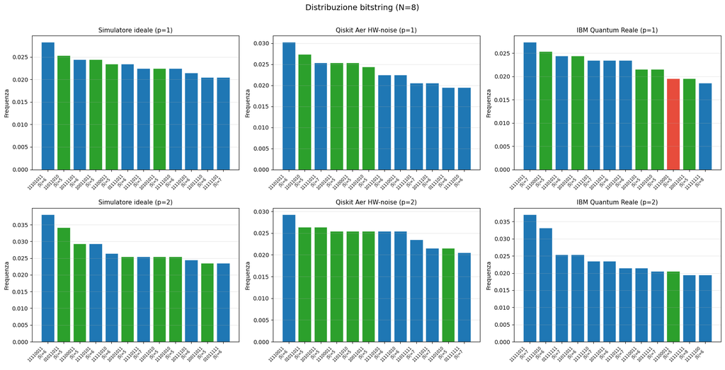

```
                         Confronto completo — PL ideale vs Aer vs IBM Quantum reale
╭──────┬──────┬────────────┬────────────┬───────────┬────────────┬────────────┬──────────────┬──────────────╮
│    N │    p │  PL ideale │    Aer id. │    Aer HW │  IBM reale │   Δ IBM−PL │  Δ IBM−AerHW │  Δ IBM−AerId │
├──────┼──────┼────────────┼────────────┼───────────┼────────────┼────────────┼──────────────┼──────────────┤
│    8 │    1 │     1.0000 │     1.0000 │    1.0000 │     1.0000 │    +0.0000 │      +0.0000 │      +0.0000 │
│    8 │    2 │     1.0000 │     1.0000 │    1.0000 │     1.0000 │    +0.0000 │      +0.0000 │      +0.0000 │
╰──────┴──────┴────────────┴────────────┴───────────┴────────────┴────────────┴──────────────┴──────────────╯
```

```python
if "IBM_RES" in locals() and IBM_RES:
    n_val = IBM_N
    G_cmp = ALL[n_val][IBM_IID]
    iid   = G_cmp.graph["instance_id"]

    opt_cmp = next(r.sz for r in CLASSICAL
                   if r.solver == "branch_and_bound" and r.n == n_val and r.iid == iid)

    counts_ideal_by_p, counts_aer_by_p, counts_ibm_by_p = {}, {}, {}
    p_to_plot = IBM_P_LIST

    for p_val in p_to_plot:
        params_cmp = OPT_PARAMS.get((n_val, iid, p_val))
        if params_cmp is None:
            continue
        _, ci = sample_aer(G_cmp, p_val, params_cmp, noisy=False)
        counts_ideal_by_p[p_val] = ci
        _, ca = sample_aer(G_cmp, p_val, params_cmp, noisy=True)
        counts_aer_by_p[p_val] = ca
        ibm_c = next((r["counts"] for r in IBM_RES if r["p"] == p_val and r["n"] == n_val), {})
        counts_ibm_by_p[p_val] = ibm_c

    plot_ibm_comparison(ideal_counts_by_p=counts_ideal_by_p,
                        aer_counts_by_p=counts_aer_by_p,
                        ibm_counts_by_p=counts_ibm_by_p,
                        G=G_cmp, opt=opt_cmp, p_list=p_to_plot, n_shots=N_SHOTS)

    # Confronto single-instance: PL, Aer e IBM tutti sullo stesso grafo (iid=20)
    print_ibm_comparison_table(QAOA_RES, AER_RES, IBM_RES, [n_val], p_to_plot, iid=iid)
else:
    print("Nessun risultato IBM — tabella e grafici non generabili.")
```

La tabella mostra che tutte le configurazioni raggiungono ($\text{ratio}=1.000$) sia per ($p=1$) sia per ($p=2$). Preso da solo, questo risultato potrebbe suggerire che il rumore abbia un impatto trascurabile e che hardware reale e simulatori abbiano prestazioni equivalenti.

Le distribuzioni mostrano però un quadro diverso. In tutti i casi la probabilità è distribuita su molte cover valide e non concentrata su un singolo bitstring ottimo. In particolare, su IBM, a ($p=1$) compare tra gli stati più frequenti anche una configurazione non valida, mentre a ($p=2$) il bitstring più probabile non è una soluzione ottima, ma solamente valida.

La spiegazione è che il ratio, su questa istanza, è una metrica satura. Il grafo ammette numerose coperture minime e il criterio adottato verifica soltanto se almeno una soluzione ottima compare nei 1024 shot. Di conseguenza, anche distribuzioni molto diverse possono produrre lo stesso valore finale ($\text{ratio}=1.000$).

Per questo motivo la metrica più informativa è ($p_\text{opt}$), che misura direttamente la probabilità di campionare una soluzione ottima.

```python
G_     = ALL[IBM_N][IBM_IID]
nodes_ = list(G_.nodes())
opt_   = next(r.sz for r in CLASSICAL
              if r.solver == "branch_and_bound" and r.n == IBM_N and r.iid == IBM_IID)
for p_val in IBM_P_LIST:
    ibm_r = next((r for r in IBM_RES if r["p"] == p_val and r["n"] == IBM_N), None)
    if ibm_r is None: continue
    params = OPT_PARAMS[(IBM_N, IBM_IID, p_val)]
    _, ci = sample_aer(G_, p_val, params, n_shots=1024, noisy=False)
    _, ch = sample_aer(G_, p_val, params, n_shots=1024, noisy=True)
    pid, _, _ = calc_probs(G_, nodes_, opt_, ci)
    phw, _, _ = calc_probs(G_, nodes_, opt_, ch)
    print(f"p={p_val}:  ratio_IBM={ibm_r['ratio']:.3f}  |  "
          f"p_opt  IBM={ibm_r['p_opt']:.3f}  Aer-id={pid:.3f}  Aer-HW={phw:.3f}  "
          f"|  backend={ibm_r['backend']}")
```

```
p=1:  ratio_IBM=1.000  |  p_opt  IBM=0.169  Aer-id=0.185  Aer-HW=0.190  |  backend=ibm_marrakesh
p=2:  ratio_IBM=1.000  |  p_opt  IBM=0.117  Aer-id=0.217  Aer-HW=0.199  |  backend=ibm_fez
```

A ($p=1$) IBM, Aer-HW e Aer ideale restano vicini (rispettivamente $0.169$, $0.190$, $0.185$), indicando che il noise model riproduce correttamente il comportamento dell'hardware a bassa profondità. A ($p=2$) invece, IBM scende a $(p_\text{opt}=0.117)$, mentre Aer-HW e Aer ideale rimangono alti, rispettivamente a $(0.199)$ e $(0.217)$: il divario si amplifica e il degrado osservato sull'hardware reale è quindi maggiore di quello previsto dal noise model.

Nel complesso, i risultati (in particolare, il confronto su $p_{opt}$) suggeriscono che il modello di rumore di Aer fornisca una stima affidabile a profondità ridotta, ma tenda a sottostimare gli effetti del rumore quando la profondità del circuito aumenta. Il confronto tra profondità deve quindi essere interpretato come indicativo e non conclusivo.

## 5. Confronti e Sviluppi Futuri

Questa sezione raccoglie tutti i risultati in un confronto unificato su tre livelli: qualità delle soluzioni (approximation ratio), costo computazionale (tempi di esecuzione), e validazione su hardware reale.

Il confronto utilizza PennyLane ideale, che è risultato il migliore nell'analisi precedente, con best $p$ per istanza. I risultati IBM non sono inclusi perchè sono limitati dalla quota a una singola istanza rappresentativa e a $p \leq 2$, e su quell'istanza il ratio è saturo ($1.000$ per tutti i metodi, simulatori inclusi), quindi non discriminante.

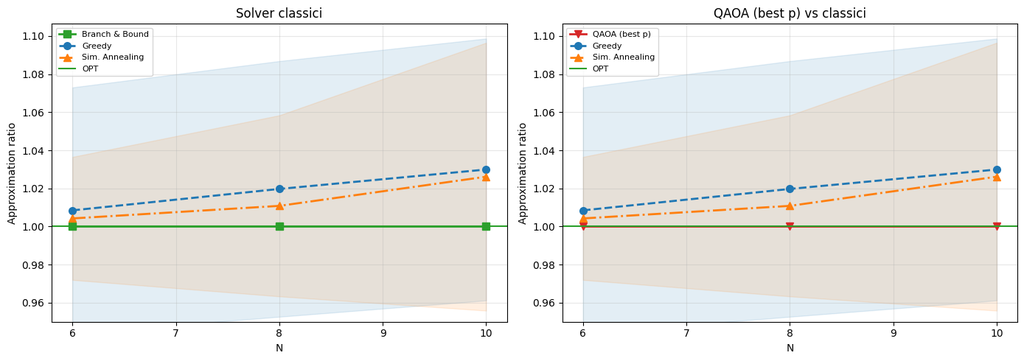

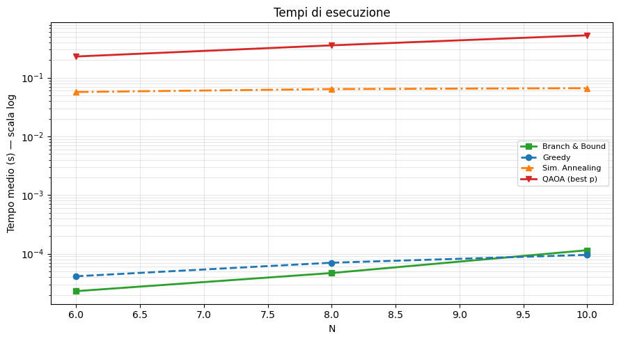

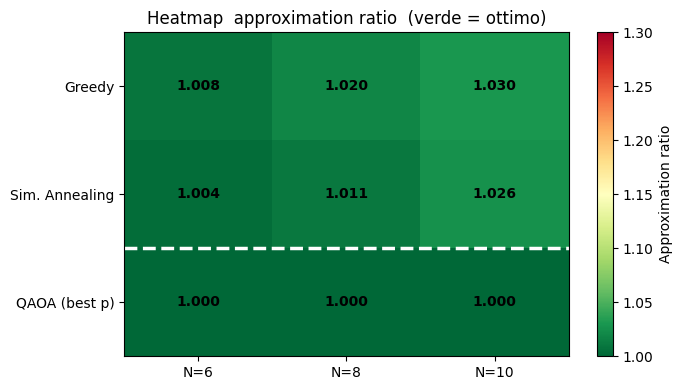

```
                    Confronto finale — classici vs QAOA (best p)
╔══════════════════════╤════════════╤════════════╤════════════╤════════════╤════════╗
║ Solver               │  Avg Ratio │  Std Ratio │  Max Ratio │  Avg t (s) │      n ║
╟──────────────────────┼────────────┼────────────┼────────────┼────────────┼────────╢
║ Branch & Bound       │     1.0000 │     0.0000 │     1.0000 │     0.0001 │    180 ║
║ Greedy               │     1.0194 │     0.0674 │     1.5000 │     0.0001 │    179 ║
║ Sim. Annealing       │     1.0138 │     0.0533 │     1.3333 │     0.0625 │    179 ║
║ QAOA (best p)        │     1.0000 │     0.0000 │     1.0000 │     0.3716 │    179 ║
╚══════════════════════╧════════════╧════════════╧════════════╧════════════╧════════╝
```

```python
# ── 5. Confronto finale — classici vs QAOA (best p) ─────────────────────
import utils.display as _disp

_saved = _disp.ORDER_QAOA[:]
_disp.ORDER_QAOA = ["qaoa_best"]

small_cl = [r for r in CLASSICAL if r.n in SIZES]
COMPARISON_RES = small_cl + QAOA_BEST

plot_ratio_vs_n(COMPARISON_RES,
                title_cl="Solver classici",
                title_qa="QAOA (best p) vs classici")
plot_time_vs_n(COMPARISON_RES)
plot_heatmap(COMPARISON_RES, SIZES)
print_summary_table(COMPARISON_RES,
                    title="Confronto finale — classici vs QAOA (best p)")

_disp.ORDER_QAOA = _saved
```

Inoltre, valutiamo gli algoritmi in base alla metrica $p_{opt}$.

```python
if "IBM_RES" not in globals() or not IBM_RES:
    print("Nessun risultato IBM disponibile — tabella p_opt non generabile.")
else:
    G_     = ALL[IBM_N][IBM_IID]
    nodes_ = list(G_.nodes())
    opt_   = next(r.sz for r in CLASSICAL
                  if r.solver == "branch_and_bound"
                  and r.n == IBM_N and r.iid == IBM_IID)

    stats_popt_finale = {}
    for p_val in IBM_P_LIST:
        ibm_r  = next((r for r in IBM_RES
                       if r["p"] == p_val and r["n"] == IBM_N), None)
        params = OPT_PARAMS.get((IBM_N, IBM_IID, p_val))
        if ibm_r is None or params is None:
            continue

        _, ci = sample_aer(G_, p_val, params, n_shots=1024, noisy=False)
        _, ch = sample_aer(G_, p_val, params, n_shots=1024, noisy=True)
        pid, _, _ = calc_probs(G_, nodes_, opt_, ci)
        phw, _, _ = calc_probs(G_, nodes_, opt_, ch)

        stats_popt_finale[p_val] = {
            "Aer Ideale":   {"opt": [pid]},
            "Aer HW-noise": {"opt": [phw]},
            "IBM HW reale": {"opt": [ibm_r["p_opt"]]},
        }

    _disp.print_p_opt_average_table(stats_popt_finale, list(stats_popt_finale.keys()))
```

```
     p_opt Medio (p=1)           p_opt Medio (p=2)

  Configurazione    p_opt     Configurazione    p_opt
 ─────────────────────────   ─────────────────────────
  Aer Ideale       0.1846     Aer Ideale       0.2168
  Aer HW-noise     0.1904     Aer HW-noise     0.1992
  IBM HW reale     0.1689     IBM HW reale     0.1172
```

Dall'analisi dei grafici e della tabella emergono due considerazioni principali: tra i metodi classici, Simulated Annealing offre il miglior compromesso tra qualità della soluzione e tempo di esecuzione, mentre QAOA con selezione del miglior $p$ per istanza raggiunge le soluzioni più vicine all'ottimo esatto tra gli approcci euristici considerati.

**Qualità delle soluzioni.**  
QAOA con best-$p$ raggiunge un ratio medio di $1.000$, coincidente con l'ottimo esatto di Branch & Bound: la heatmap mostra $1.000$ a tutte le dimensioni ($N=6,8,10$) e deviazione standard nulla. Ricordiamo tuttavia, che questo può essere considerato un artefatto statistico dovuto alla permessività del numero di shots. Greedy e Simulated Annealing restano sopra l'ottimo, con worst-case rispettivamente $1.5000$ e $1.3333$ sulle istanze più difficili.

**Confronto con i metodi classici.**  
Greedy è tra gli algoritmi più veloci, insieme a Branch & Bound (tempi tra $\sim 10^{-5}$ e $10^{-4}$ s), ma con qualità inferiore: ratio medio $1.0194$ e la variabilità più elevata $(\mathrm{std}=0.0674)$. Simulated Annealing risulta più equilibrato, con ratio medio $1.0138$ a fronte di un tempo medio di circa $0.06$ s, mostrando una maggiore stabilità rispetto a Greedy su tutte le dimensioni. Branch & Bound rimane il riferimento esatto, ma con costo computazionale esponenziale in $N$.

**Costo computazionale di QAOA.**  
Il miglioramento qualitativo di QAOA ha un costo rilevante: il tempo medio per istanza è di circa $0.37$ s, contro circa $0.07$ s di Simulated Annealing e $\sim 10^{-4}$ s dei metodi classici più rapidi, ossia circa 3-4 ordini di grandezza in più rispetto a Greedy e Branch & Bound. Va inoltre osservato che il tempo riportato è quello della singola profondità selezionata: identificare il best-$p$ richiederebbe in pratica di eseguire tutte le profondità considerate, poiché la selezione utilizza l'ottimo esatto come oracolo. Simulated Annealing fornisce quindi un ratio solo leggermente peggiore con un costo inferiore, rappresentando il compromesso più pratico per un utilizzo generale.

**Effetto del rumore.** I risultati QAOA riportati in tabella corrispondono al caso più favorevole: best-$p$, simulatore ideale e assenza di rumore. L'analisi su hardware reale mostra che a profondità $p=1$ la probabilità di campionare una soluzione ottima resta vicina tra i tre ambienti (IBM $\approx 0.17$, simulatori $\approx 0.19$). A $p=2$, invece, i due simulatori restano alti ($\approx 0.20$), mentre l'hardware reale scende a circa $0.117$: il degrado osservato sul processore vero è quindi superiore a quello previsto dal noise model di Aer, che a questa profondità non lo coglie quasi affatto. Il vantaggio di QAOA rispetto ai metodi classici tende dunque a ridursi ulteriormente quando si considerano il rumore reale e l'aumento della profondità del circuito.

### Sviluppi Futuri

Un risultato ricorrente di questo lavoro è che non esiste una profondità di QAOA universalmente ottimale: il valore di $p$ dipende fortemente dall’istanza. Nei confronti finali, la strategia best-$p$ seleziona a posteriori la profondità che massimizza la performance, ma questo richiede l’accesso all’ottimo esatto tramite Branch & Bound e quindi non è utilizzabile in uno scenario reale.

Una possibile estensione naturale consiste nel sostituire questa procedura con un gate neurale che apprenda direttamente la scelta della profondità, interpretando QAOA come un mixture of experts in cui ogni esperto corrisponde a un diverso valore di $p$.

In questa prospettiva, ogni configurazione del circuito QAOA (cioè ogni profondità $p$) rappresenta un esperto distinto, con un diverso compromesso tra espressività del circuito e costo/rumore. Il modello non modifica il circuito in sé, ma decide quale profondità attivare per una data istanza.

Il gate riceve in input un insieme di feature strutturali dell’istanza, come il numero di nodi $N$, la densità $p_\text{edge}$ e statistiche del grafo (media, varianza e massimo del grado, dimensione di coperture iniziali o matching approssimati). A partire da queste informazioni, una rete neurale stima la performance attesa per ciascun valore di $p$, in termini di approximation ratio e stabilità statistica.

La decisione finale consiste quindi nel routing: $$\text{feature dell’istanza} \quad \longrightarrow \quad p^\ast$$ cioè, a partire dalle features del grafo, il gate opera la selezione della profondità che massimizza il trade-off tra qualità della soluzione e costo computazionale. In questo modo si elimina la necessità di eseguire tutte le profondità e si rimuove la dipendenza dall’oracolo esatto, ammortizzando il costo della selezione su molte istanze.

Il training può essere costruito direttamente dai dati del benchmark, che contengono le prestazioni di QAOA per diversi valori di $p$ su ciascuna istanza. La rete apprenderebbe quindi a predire quale profondità è più promettente senza dover risolvere esattamente il problema.

Possibili estensioni includono l’introduzione di una loss costo-consapevole, in cui oltre alla qualità della soluzione viene penalizzato anche il costo computazionale del circuito, rendendo esplicito il trade-off tra accuratezza e risorse. Un’ulteriore direzione consiste nell’integrare informazioni sul rumore hardware (tassi di errore dei gate, $T_1$, $T_2$), così da permettere al modello di adattare la scelta di $p$ anche in regime noisy intermediate-scale quantum.

Infine, un aspetto rilevante riguarda la generalizzazione: addestrare il gate su istanze piccole e verificare la capacità del modello di trasferire la scelta della profondità a grafi più grandi rappresenta un passo cruciale verso un utilizzo scalabile di QAOA come sistema adattivo.